# Análisis de Componentes Principales (PCA) — Leonard et al. (2020)

### Score plots — Tiempo

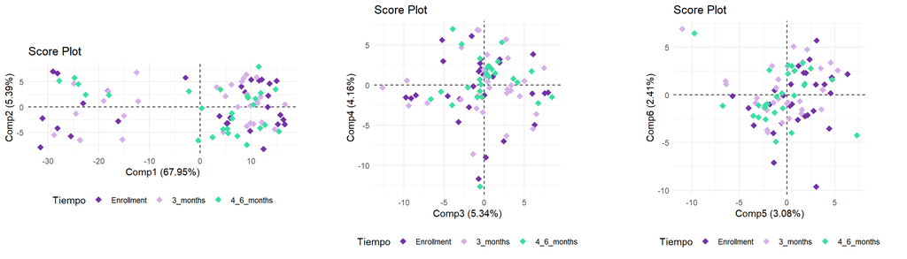

```r
p1 <- pcaPlot(pathways_pca_ctr, type = "scores", comp = 1:2,
              colBy = data.frame(Tiempo = pathways_time),
              labels = FALSE, ellipses = FALSE)
p2 <- pcaPlot(pathways_pca_ctr, type = "scores", comp = 3:4,
              colBy = data.frame(Tiempo = pathways_time),
              labels = FALSE, ellipses = FALSE)
p3 <- pcaPlot(pathways_pca_ctr, type = "scores", comp = 5:6,
              colBy = data.frame(Tiempo = pathways_time),
              labels = FALSE, ellipses = FALSE)
grid.arrange(p1, p2, p3, nrow = 1)
```

### Score plots — País

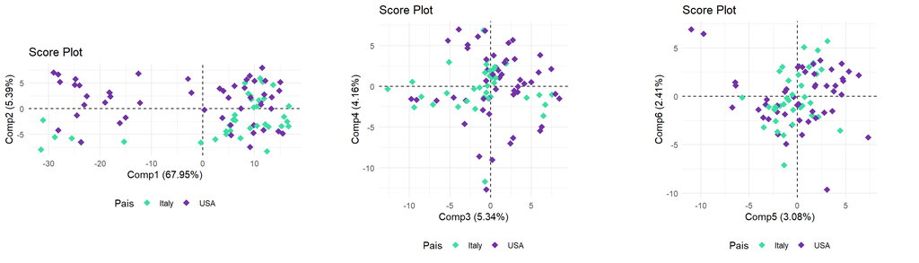

```r
p1 <- pcaPlot(pathways_pca_ctr, type = "scores", comp = 1:2,
              colBy = data.frame(Pais = pathways_meta$country),
              labels = FALSE, ellipses = FALSE)
p2 <- pcaPlot(pathways_pca_ctr, type = "scores", comp = 3:4,
              colBy = data.frame(Pais = pathways_meta$country),
              labels = FALSE, ellipses = FALSE)
p3 <- pcaPlot(pathways_pca_ctr, type = "scores", comp = 5:6,
              colBy = data.frame(Pais = pathways_meta$country),
              labels = FALSE, ellipses = FALSE)
grid.arrange(p1, p2, p3, nrow = 1)
```

### Score plots — Modo de parto

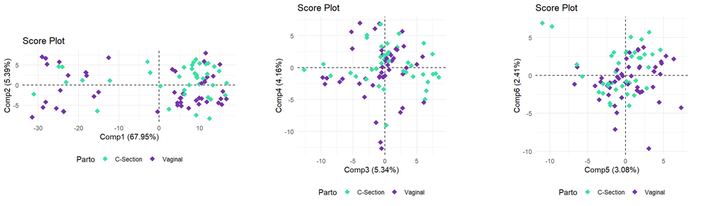

```r
p1 <- pcaPlot(pathways_pca_ctr, type = "scores", comp = 1:2,
              colBy = data.frame(Parto = pathways_meta$Delivery_Mode),
              labels = FALSE, ellipses = FALSE)
p2 <- pcaPlot(pathways_pca_ctr, type = "scores", comp = 3:4,
              colBy = data.frame(Parto = pathways_meta$Delivery_Mode),
              labels = FALSE, ellipses = FALSE)
p3 <- pcaPlot(pathways_pca_ctr, type = "scores", comp = 5:6,
              colBy = data.frame(Parto = pathways_meta$Delivery_Mode),
              labels = FALSE, ellipses = FALSE)
grid.arrange(p1, p2, p3, nrow = 1)
```

### Score plots — Tipo de alimentación

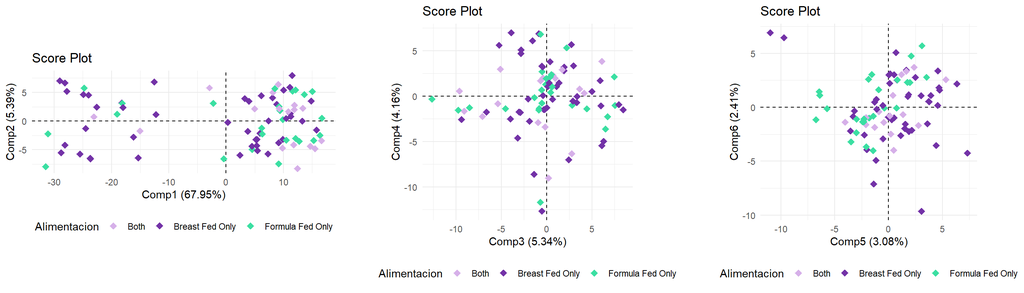

```r
p1 <- pcaPlot(pathways_pca_ctr, type = "scores", comp = 1:2,
              colBy = data.frame(Alimentacion = pathways_meta$Feeding_Type),
              labels = FALSE, ellipses = FALSE)
p2 <- pcaPlot(pathways_pca_ctr, type = "scores", comp = 3:4,
              colBy = data.frame(Alimentacion = pathways_meta$Feeding_Type),
              labels = FALSE, ellipses = FALSE)
p3 <- pcaPlot(pathways_pca_ctr, type = "scores", comp = 5:6,
              colBy = data.frame(Alimentacion = pathways_meta$Feeding_Type),
              labels = FALSE, ellipses = FALSE)
grid.arrange(p1, p2, p3, nrow = 1)
```

### Score plots — Sexo

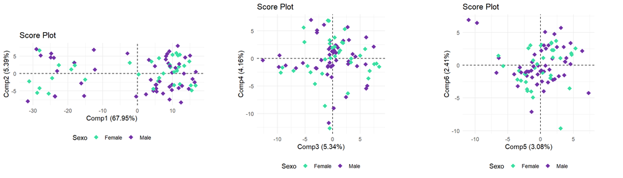

```r
p1 <- pcaPlot(pathways_pca_ctr, type = "scores", comp = 1:2,
              colBy = data.frame(Sexo = pathways_meta$Gender),
              labels = FALSE, ellipses = FALSE)
p2 <- pcaPlot(pathways_pca_ctr, type = "scores", comp = 3:4,
              colBy = data.frame(Sexo = pathways_meta$Gender),
              labels = FALSE, ellipses = FALSE)
p3 <- pcaPlot(pathways_pca_ctr, type = "scores", comp = 5:6,
              colBy = data.frame(Sexo = pathways_meta$Gender),
              labels = FALSE, ellipses = FALSE)
grid.arrange(p1, p2, p3, nrow = 1)
```

### Loadings — Correlation plots

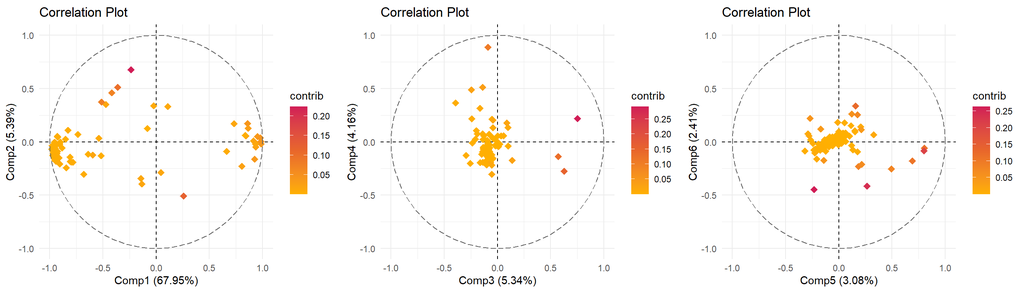

```r
l1 <- pcaPlot(pathways_pca_ctr, type = "corr", comp = 1:2,
              colBy = "contrib", shape = "point", labels = FALSE, repel = TRUE, col = "hot")
l2 <- pcaPlot(pathways_pca_ctr, type = "corr", comp = 3:4,
              colBy = "contrib", shape = "point", labels = FALSE, repel = TRUE, col = "hot")
l3 <- pcaPlot(pathways_pca_ctr, type = "corr", comp = 5:6,
              colBy = "contrib", shape = "point", labels = FALSE, repel = TRUE, col = "hot")
grid.arrange(l1, l2, l3, ncol = 3)
```

### Loadings — Top 10 pathways

**PC1 y PC2**

```r
tibble(
  variable    = rownames(pathways_pca_ctr$loadings),
  loading_PC1 = pathways_pca_ctr$loadings[, 1],
  loading_PC2 = pathways_pca_ctr$loadings[, 2]
) %>%
  mutate(contribution_PC12 = loading_PC1^2 + loading_PC2^2) %>%
  arrange(desc(contribution_PC12)) %>%
  slice_head(n = 10) %>%
  kable(caption = "Centrado — Top 10 pathways PC1/PC2")
```

Centrado — Top 10 pathways PC1/PC2

| variable | loading_PC1 | loading_PC2 | contribution_PC12 |
| --- | --- | --- | --- |
| Atrazine.degradation | -0.0463908 | 0.4716494 | 0.2246052 |
| Biphenyl.degradation | 0.0494306 | -0.3447469 | 0.1212938 |
| Toluene.and.xylene.degradation | 0.0494306 | -0.3447469 | 0.1212938 |
| Tetrachloroethene.degradation | -0.0614950 | 0.3100507 | 0.0999131 |
| Mannose.type.O.glycan.biosynthesis | -0.0998116 | 0.2583392 | 0.0767015 |
| Styrene.degradation | -0.0654077 | 0.2577241 | 0.0706999 |
| Fluorobenzoate.degradation | -0.0654077 | 0.2577241 | 0.0706999 |
| Primary.bile.acid.biosynthesis | 0.2075871 | 0.0295915 | 0.0439681 |
| Limonene.and.pinene.degradation | 0.2075871 | 0.0295915 | 0.0439681 |
| Caprolactam.degradation | 0.2075871 | 0.0295915 | 0.0439681 |

**PC3 y PC4**

```r
tibble(
  variable    = rownames(pathways_pca_ctr$loadings),
  loading_PC3 = pathways_pca_ctr$loadings[, 3],
  loading_PC4 = pathways_pca_ctr$loadings[, 4]
) %>%
  mutate(contribution_PC34 = loading_PC3^2 + loading_PC4^2) %>%
  arrange(desc(contribution_PC34)) %>%
  slice_head(n = 10) %>%
  kable(caption = "Centrado — Top 10 pathways PC3/PC4")
```

Centrado — Top 10 pathways PC3/PC4

| variable | loading_PC3 | loading_PC4 | contribution_PC34 |
| --- | --- | --- | --- |
| Biphenyl.degradation | 0.5126647 | 0.1699244 | 0.2916994 |
| Toluene.and.xylene.degradation | 0.5126647 | 0.1699244 | 0.2916994 |
| Styrene.degradation | 0.3512313 | -0.1741575 | 0.1536943 |
| Fluorobenzoate.degradation | 0.3512313 | -0.1741575 | 0.1536943 |
| Tetrachloroethene.degradation | 0.3483029 | -0.0955958 | 0.1304534 |
| Thermogenesis | -0.0287191 | 0.3250236 | 0.1064651 |
| PI3K.Akt.signaling.pathway | -0.0287191 | 0.3250236 | 0.1064651 |
| mTOR.signaling.pathway | -0.0287191 | 0.3250236 | 0.1064651 |
| Relaxin.signaling.pathway | -0.0287191 | 0.3250236 | 0.1064651 |
| Human.papillomavirus.infection | -0.0287191 | 0.3250236 | 0.1064651 |

**PC5 y PC6**

```r
tibble(
  variable    = rownames(pathways_pca_ctr$loadings),
  loading_PC5 = pathways_pca_ctr$loadings[, 5],
  loading_PC6 = pathways_pca_ctr$loadings[, 6]
) %>%
  mutate(contribution_PC56 = loading_PC5^2 + loading_PC6^2) %>%
  arrange(desc(contribution_PC56)) %>%
  slice_head(n = 10) %>%
  kable(caption = "Centrado — Top 10 pathways PC5/PC6")
```

Centrado — Top 10 pathways PC5/PC6

| variable | loading_PC5 | loading_PC6 | contribution_PC56 |
| --- | --- | --- | --- |
| Atrazine.degradation | -0.2142987 | -0.4672500 | 0.2642465 |
| Mannose.type.O.glycan.biosynthesis | 0.2431299 | -0.4295827 | 0.2436535 |
| Sulfur.metabolism | 0.4523066 | -0.0543128 | 0.2075312 |
| Phosphonate.and.phosphinate.metabolism | 0.1344165 | 0.3266764 | 0.1247853 |
| Lipoic.acid.metabolism | 0.3377596 | -0.0271716 | 0.1148199 |
| Lipopolysaccharide.biosynthesis | 0.3149211 | -0.0922318 | 0.1076820 |
| Lysine.degradation | 0.1676298 | -0.2375386 | 0.0845243 |
| Riboflavin.metabolism | 0.2431201 | -0.1420186 | 0.0792767 |
| Tetrachloroethene.degradation | 0.1404700 | 0.2315853 | 0.0733636 |
| Tryptophan.metabolism | 0.1732506 | -0.1918029 | 0.0668041 |

```r
pathways_pca_ctr <- pca(
  pathways_X,
  ncomp   = 2,
  algo    = "nipals",
  scaling = "center"
)
```

### Detección de muestras anómalas (centrado)

```r
par(mfrow = c(1, 2))

pathways_out_RSS_ctr <- pcaOutliers(pathways_pca_ctr, ncomp = pathways_pca_ctr$ncomp, method = "RSS", conf = 0.95)
pathways_out_T2_ctr  <- pcaOutliers(pathways_pca_ctr, ncomp = pathways_pca_ctr$ncomp, method = "T2",  conf = 0.95)
```

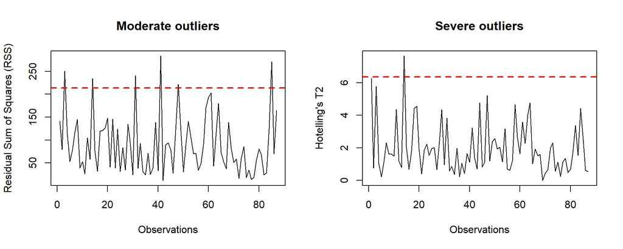

```r
par(mfrow = c(1, 1))
```

```r
pathways_moderate_ctr <- sort(
  pathways_out_RSS_ctr$RSS[pathways_out_RSS_ctr$ModerateOutliers],
  decreasing = TRUE
)

pathways_severe_ctr <- sort(
  pathways_out_T2_ctr$T2[pathways_out_T2_ctr$SevereOutliers],
  decreasing = TRUE
)

cat("Anómalos moderados (RSS) al 95 :\n"); print(pathways_moderate_ctr)
```

```
## Anómalos moderados (RSS) al 95 :
```

```
##   subject_23_3_months  subject_1_4_6_months  subject_8_Enrollment
##              283.6076              271.2905              250.8648
##    subject_6_3_months subject_24_Enrollment   subject_30_3_months
##              240.9549              234.4845              221.3634
```

```r
cat("\nAnómalos severos (T²) al 95 :\n");   print(pathways_severe_ctr)
```

```
##
## Anómalos severos (T²) al 95 :
```

```
## subject_24_Enrollment
##              7.642118
```

```r
par(mfrow = c(1, 2))

pathways_out_RSS_99_ctr <- pcaOutliers(pathways_pca_ctr, ncomp = pathways_pca_ctr$ncomp, method = "RSS", conf = 0.99)
pathways_out_T2_99_ctr  <- pcaOutliers(pathways_pca_ctr, ncomp = pathways_pca_ctr$ncomp, method = "T2",  conf = 0.99)
```

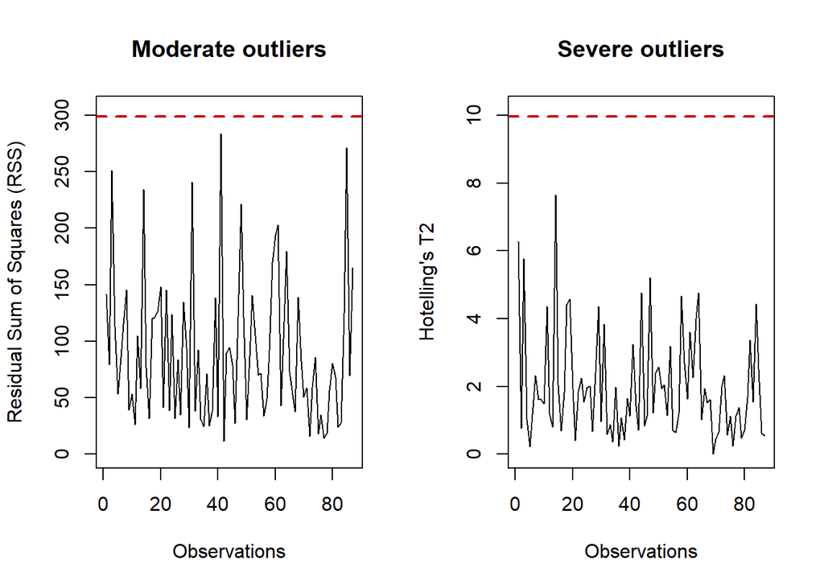

```r
par(mfrow = c(1, 1))
```

```r
pw_moderate_99_ctr <- sort(pathways_out_RSS_99_ctr$RSS[pathways_out_RSS_99_ctr$ModerateOutliers], decreasing = TRUE)
pw_severe_99_ctr   <- sort(pathways_out_T2_99_ctr$T2[pathways_out_T2_99_ctr$SevereOutliers], decreasing = TRUE)

cat("Moderados (RSS) al 99 :\n"); print(pw_moderate_99_ctr)
```

```
## Moderados (RSS) al 99 :
```

```
## named numeric(0)
```

```r
cat("Severos   (T²) al 99 :\n");  print(pw_severe_99_ctr)
```

```
## Severos   (T²) al 99 :
```

```
## named numeric(0)
```

```r
pw_mod_contrib_99_ctr <- outlierContrib(pathways_pca_ctr, pathways_out_RSS_99_ctr)
```

```
## There are no severe outliers in the data or they were not computed.
```

```
## There are no moderate outliers in the data or they were not computed.
```

```r
pw_top10_moderate_ctr <- get_top_contrib_list(pw_mod_contrib_99_ctr$contribRSS)
pw_top10_moderate_ctr
```

```
## list()
```

```r
pw_sev_contrib_99_ctr <- outlierContrib(pathways_pca_ctr, pathways_out_T2_99_ctr)
```

```
## There are no severe outliers in the data or they were not computed.
```

```
## There are no moderate outliers in the data or they were not computed.
```

```r
pw_top10_severe_ctr   <- get_top_contrib_list(pw_sev_contrib_99_ctr$contribT2)
pw_top10_severe_ctr
```

```
## list()
```

## Escalado estándar (`scaling = "standard"`)

### Cálculo y scree plot

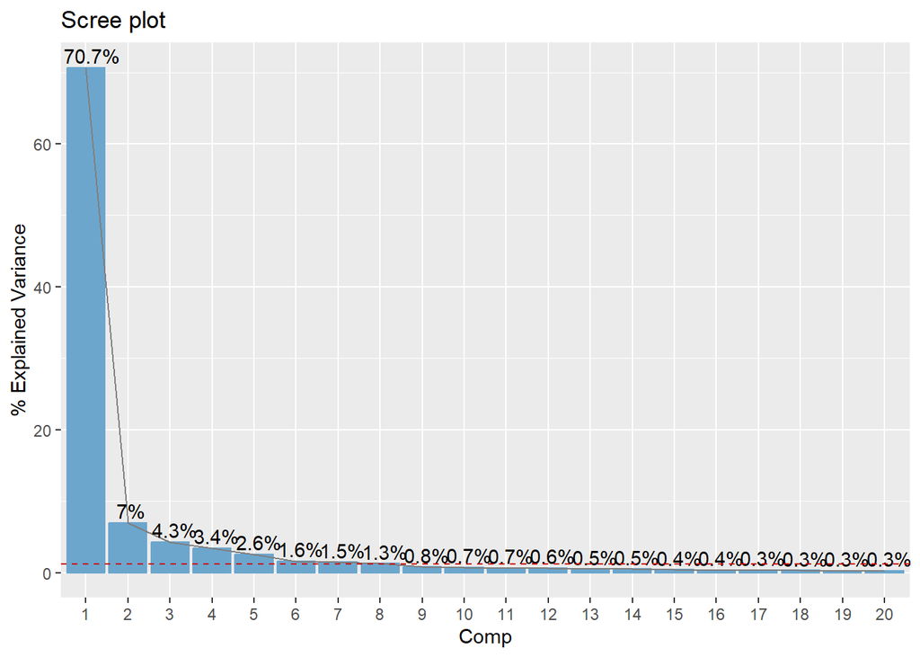

```r
pathways_pca_std <- pca(pathways_X, ncomp = NULL, algo = "nipals", scaling = "standard")
pcaPlot(pathways_pca_std, type = "scree")
```

### Score plots — Exposición ambiental

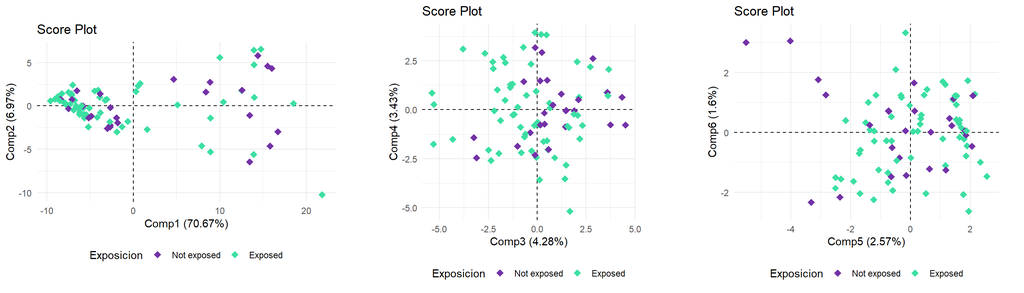

```r
p1 <- pcaPlot(pathways_pca_std, type = "scores", comp = 1:2,
              colBy = data.frame(Exposicion = pathways_meta$Exposure_to_Environmental_Factors),
              labels = FALSE, ellipses = FALSE)
p2 <- pcaPlot(pathways_pca_std, type = "scores", comp = 3:4,
              colBy = data.frame(Exposicion = pathways_meta$Exposure_to_Environmental_Factors),
              labels = FALSE, ellipses = FALSE)
p3 <- pcaPlot(pathways_pca_std, type = "scores", comp = 5:6,
              colBy = data.frame(Exposicion = pathways_meta$Exposure_to_Environmental_Factors),
              labels = FALSE, ellipses = FALSE)
grid.arrange(p1, p2, p3, nrow = 1)
```

### Score plots — Riesgo genético

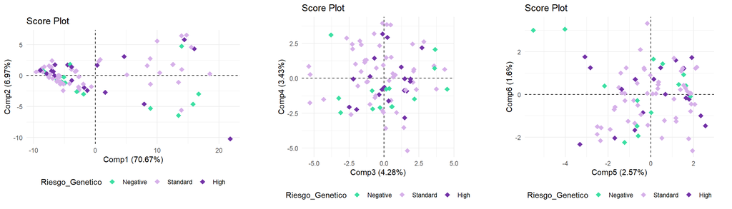

```r
p1 <- pcaPlot(pathways_pca_std, type = "scores", comp = 1:2,
              colBy = data.frame(Riesgo_Genetico = pathways_meta$Genetic_Risk_Group),
              labels = FALSE, ellipses = FALSE)
p2 <- pcaPlot(pathways_pca_std, type = "scores", comp = 3:4,
              colBy = data.frame(Riesgo_Genetico = pathways_meta$Genetic_Risk_Group),
              labels = FALSE, ellipses = FALSE)
p3 <- pcaPlot(pathways_pca_std, type = "scores", comp = 5:6,
              colBy = data.frame(Riesgo_Genetico = pathways_meta$Genetic_Risk_Group),
              labels = FALSE, ellipses = FALSE)
grid.arrange(p1, p2, p3, nrow = 1)
```

### Score plots — Tiempo

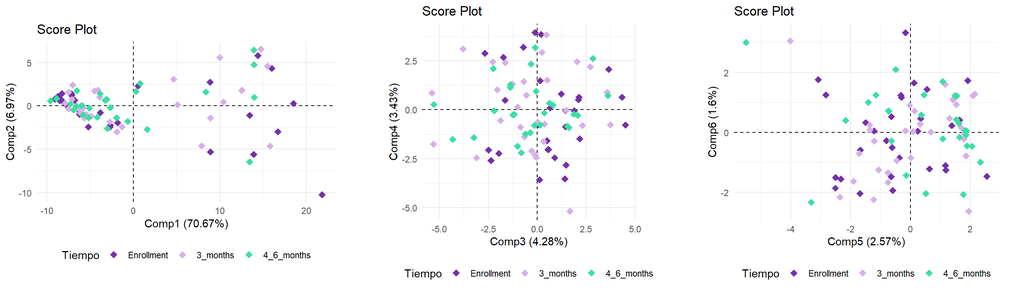

```r
p1 <- pcaPlot(pathways_pca_std, type = "scores", comp = 1:2,
              colBy = data.frame(Tiempo = pathways_time),
              labels = FALSE, ellipses = FALSE)
p2 <- pcaPlot(pathways_pca_std, type = "scores", comp = 3:4,
              colBy = data.frame(Tiempo = pathways_time),
              labels = FALSE, ellipses = FALSE)
p3 <- pcaPlot(pathways_pca_std, type = "scores", comp = 5:6,
              colBy = data.frame(Tiempo = pathways_time),
              labels = FALSE, ellipses = FALSE)
grid.arrange(p1, p2, p3, nrow = 1)
```

### Score plots — País

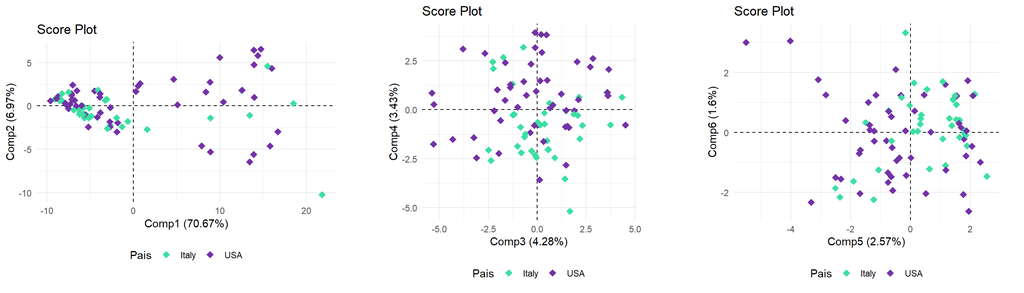

```r
p1 <- pcaPlot(pathways_pca_std, type = "scores", comp = 1:2,
              colBy = data.frame(Pais = pathways_meta$country),
              labels = FALSE, ellipses = FALSE)
p2 <- pcaPlot(pathways_pca_std, type = "scores", comp = 3:4,
              colBy = data.frame(Pais = pathways_meta$country),
              labels = FALSE, ellipses = FALSE)
p3 <- pcaPlot(pathways_pca_std, type = "scores", comp = 5:6,
              colBy = data.frame(Pais = pathways_meta$country),
              labels = FALSE, ellipses = FALSE)
grid.arrange(p1, p2, p3, nrow = 1)
```

### Score plots — Modo de parto

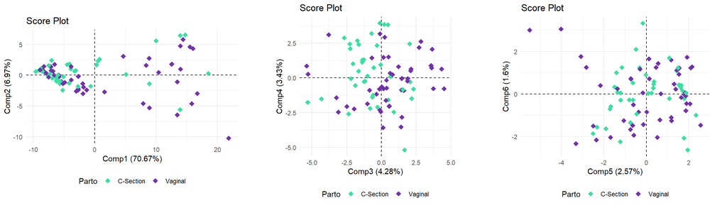

```r
p1 <- pcaPlot(pathways_pca_std, type = "scores", comp = 1:2,
              colBy = data.frame(Parto = pathways_meta$Delivery_Mode),
              labels = FALSE, ellipses = FALSE)
p2 <- pcaPlot(pathways_pca_std, type = "scores", comp = 3:4,
              colBy = data.frame(Parto = pathways_meta$Delivery_Mode),
              labels = FALSE, ellipses = FALSE)
p3 <- pcaPlot(pathways_pca_std, type = "scores", comp = 5:6,
              colBy = data.frame(Parto = pathways_meta$Delivery_Mode),
              labels = FALSE, ellipses = FALSE)
grid.arrange(p1, p2, p3, nrow = 1)
```

### Score plots — Tipo de alimentación

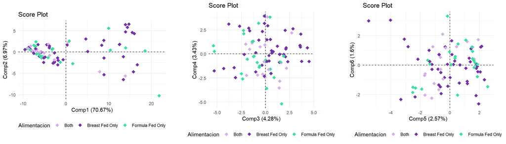

```r
p1 <- pcaPlot(pathways_pca_std, type = "scores", comp = 1:2,
              colBy = data.frame(Alimentacion = pathways_meta$Feeding_Type),
              labels = FALSE, ellipses = FALSE)
p2 <- pcaPlot(pathways_pca_std, type = "scores", comp = 3:4,
              colBy = data.frame(Alimentacion = pathways_meta$Feeding_Type),
              labels = FALSE, ellipses = FALSE)
p3 <- pcaPlot(pathways_pca_std, type = "scores", comp = 5:6,
              colBy = data.frame(Alimentacion = pathways_meta$Feeding_Type),
              labels = FALSE, ellipses = FALSE)
grid.arrange(p1, p2, p3, nrow = 1)
```

### Score plots — Sexo

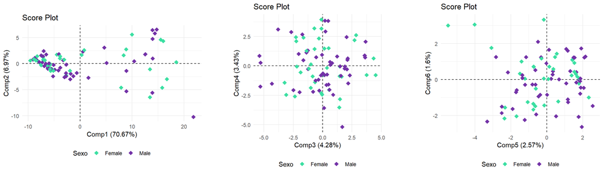

```r
p1 <- pcaPlot(pathways_pca_std, type = "scores", comp = 1:2,
              colBy = data.frame(Sexo = pathways_meta$Gender),
              labels = FALSE, ellipses = FALSE)
p2 <- pcaPlot(pathways_pca_std, type = "scores", comp = 3:4,
              colBy = data.frame(Sexo = pathways_meta$Gender),
              labels = FALSE, ellipses = FALSE)
p3 <- pcaPlot(pathways_pca_std, type = "scores", comp = 5:6,
              colBy = data.frame(Sexo = pathways_meta$Gender),
              labels = FALSE, ellipses = FALSE)
grid.arrange(p1, p2, p3, nrow = 1)
```

### Loadings — Correlation plots

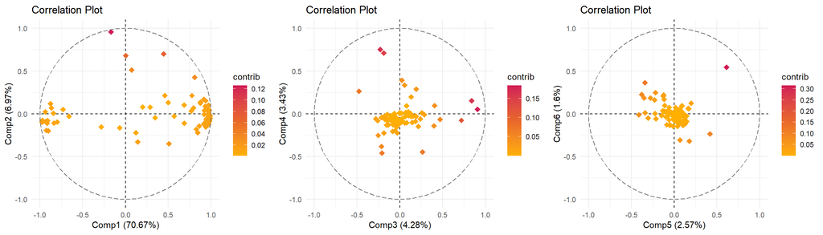

```r
l1 <- pcaPlot(pathways_pca_std, type = "corr", comp = 1:2,
              colBy = "contrib", shape = "point", labels = FALSE, repel = TRUE, col = "hot")
l2 <- pcaPlot(pathways_pca_std, type = "corr", comp = 3:4,
              colBy = "contrib", shape = "point", labels = FALSE, repel = TRUE, col = "hot")
l3 <- pcaPlot(pathways_pca_std, type = "corr", comp = 5:6,
              colBy = "contrib", shape = "point", labels = FALSE, repel = TRUE, col = "hot")
grid.arrange(l1, l2, l3, ncol = 3)
```

### Loadings — Top 10 pathways

**PC1 y PC2**

```r
tibble(
  variable    = rownames(pathways_pca_std$loadings),
  loading_PC1 = pathways_pca_std$loadings[, 1],
  loading_PC2 = pathways_pca_std$loadings[, 2]
) %>%
  mutate(contribution_PC12 = loading_PC1^2 + loading_PC2^2) %>%
  arrange(desc(contribution_PC12)) %>%
  slice_head(n = 10) %>%
  kable(caption = "Estándar — Top 10 pathways PC1/PC2")
```

Estándar — Top 10 pathways PC1/PC2

| variable | loading_PC1 | loading_PC2 | contribution_PC12 |
| --- | --- | --- | --- |
| Thermogenesis | -0.0197157 | 0.3541170 | 0.1257876 |
| PI3K.Akt.signaling.pathway | -0.0197157 | 0.3541170 | 0.1257876 |
| mTOR.signaling.pathway | -0.0197157 | 0.3541170 | 0.1257876 |
| Relaxin.signaling.pathway | -0.0197157 | 0.3541170 | 0.1257876 |
| Human.papillomavirus.infection | -0.0197157 | 0.3541170 | 0.1257876 |
| Aflatoxin.biosynthesis | 0.0517198 | 0.2592456 | 0.0698832 |
| Glycerolipid.metabolism | 0.0004507 | 0.2511663 | 0.0630847 |
| beta.Alanine.metabolism | 0.0083647 | 0.1898508 | 0.0361133 |
| Fatty.acid.biosynthesis | 0.0940678 | 0.1578708 | 0.0337719 |
| Riboflavin.metabolism | 0.0591640 | -0.1293319 | 0.0202271 |

**PC3 y PC4**

```r
tibble(
  variable    = rownames(pathways_pca_std$loadings),
  loading_PC3 = pathways_pca_std$loadings[, 3],
  loading_PC4 = pathways_pca_std$loadings[, 4]
) %>%
  mutate(contribution_PC34 = loading_PC3^2 + loading_PC4^2) %>%
  arrange(desc(contribution_PC34)) %>%
  slice_head(n = 10) %>%
  kable(caption = "Estándar — Top 10 pathways PC3/PC4")
```

Estándar — Top 10 pathways PC3/PC4

| variable | loading_PC3 | loading_PC4 | contribution_PC34 |
| --- | --- | --- | --- |
| Lipoic.acid.metabolism | 0.4284354 | 0.0284491 | 0.1843662 |
| Styrene.degradation | -0.1076914 | 0.3961183 | 0.1685071 |
| Fluorobenzoate.degradation | -0.1076914 | 0.3961183 | 0.1685071 |
| Sulfur.metabolism | 0.3963527 | 0.0806656 | 0.1636024 |
| Tetrachloroethene.degradation | -0.0884468 | 0.3748119 | 0.1483068 |
| Lipopolysaccharide.biosynthesis | 0.3398659 | -0.0404521 | 0.1171452 |
| beta.Alanine.metabolism | 0.1248477 | -0.2354261 | 0.0710124 |
| Atrazine.degradation | -0.2255333 | 0.1393460 | 0.0702826 |
| Phenylalanine.metabolism | -0.0987096 | -0.2418164 | 0.0682187 |
| Glycerophospholipid.metabolism | -0.1011748 | -0.2009965 | 0.0506359 |

**PC5 y PC6**

```r
tibble(
  variable    = rownames(pathways_pca_std$loadings),
  loading_PC5 = pathways_pca_std$loadings[, 5],
  loading_PC6 = pathways_pca_std$loadings[, 6]
) %>%
  mutate(contribution_PC56 = loading_PC5^2 + loading_PC6^2) %>%
  arrange(desc(contribution_PC56)) %>%
  slice_head(n = 10) %>%
  kable(caption = "Estándar — Top 10 pathways PC5/PC6")
```

Estándar — Top 10 pathways PC5/PC6

| variable | loading_PC5 | loading_PC6 | contribution_PC56 |
| --- | --- | --- | --- |
| Biphenyl.degradation | 0.3730864 | 0.4195570 | 0.3152215 |
| Toluene.and.xylene.degradation | 0.3730864 | 0.4195570 | 0.3152215 |
| Lipopolysaccharide.biosynthesis | -0.2079877 | 0.2793228 | 0.1212802 |
| Pentose.and.glucuronate.interconversions | 0.2556840 | -0.1819828 | 0.0984920 |
| beta.Alanine.metabolism | -0.2314292 | 0.1731565 | 0.0835426 |
| Phosphonate.and.phosphinate.metabolism | 0.1083122 | -0.2468333 | 0.0726582 |
| Riboflavin.metabolism | -0.2141941 | 0.1430452 | 0.0663410 |
| Atrazine.degradation | -0.2516857 | -0.0089839 | 0.0634264 |
| Streptomycin.biosynthesis | 0.0411872 | -0.2379991 | 0.0583400 |
| Glycerolipid.metabolism | -0.1325126 | 0.1906543 | 0.0539087 |

```r
pathways_pca_std <- pca(
  pathways_X,
  ncomp   = 2,
  algo    = "nipals",
  scaling = "standard"
)
```

## 4.4 Detección de muestras anómalas

Se detectan muestras anómalas mediante dos criterios complementarios. El RSS y el T² de Hotelling. Las muestras detectadas se identifican pero **no se eliminan**.

```r
par(mfrow = c(1, 2))

pathways_out_RSS <- pcaOutliers(pathways_pca_std, ncomp = pathways_pca_std$ncomp,method = "RSS", conf = 0.95)
pathways_out_T2  <- pcaOutliers(pathways_pca_std, ncomp = pathways_pca_std$ncomp,method = "T2",  conf = 0.95)
```

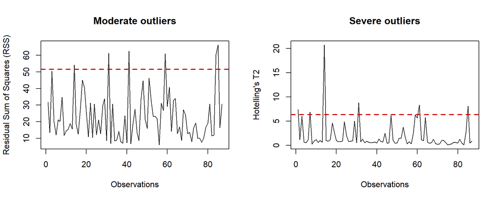

```r
par(mfrow = c(1, 1))
```

```r
pathways_moderate <- sort(
  pathways_out_RSS$RSS[pathways_out_RSS$ModerateOutliers],
  decreasing = TRUE
)

pathways_severe <- sort(
  pathways_out_T2$T2[pathways_out_T2$SevereOutliers],
  decreasing = TRUE
)

cat("Anómalos moderados (RSS) al 95 :\n"); print(pathways_moderate)
```

```
## Anómalos moderados (RSS) al 95 :
```

```
##  subject_1_4_6_months   subject_23_3_months    subject_6_3_months
##              66.21454              62.57492              61.25549
##    subject_1_3_months  subject_3_4_6_months subject_24_Enrollment
##              60.97773              60.39438              54.21230
```

```r
cat("\nAnómalos severos (T²) al 95 :\n");   print(pathways_severe)
```

```
##
## Anómalos severos (T²) al 95 :
```

```
## subject_24_Enrollment    subject_6_3_months  subject_6_4_6_months
##             20.741547              8.802915              8.334504
##  subject_1_4_6_months  subject_5_Enrollment subject_13_Enrollment
##              8.128017              7.444036              6.907693
```

```r
par(mfrow = c(1, 2))

pathways_out_RSS_99 <- pcaOutliers(pathways_pca_std, ncomp = pathways_pca_std$ncomp,method = "RSS", conf = 0.99)
pathways_out_T2_99  <- pcaOutliers(pathways_pca_std, ncomp = pathways_pca_std$ncomp,method = "T2",  conf = 0.99)
```

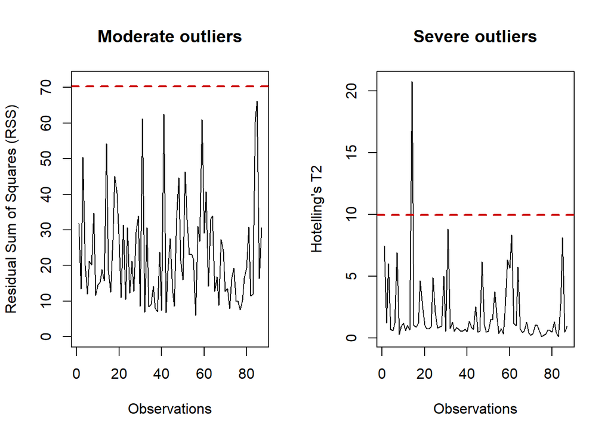

```r
par(mfrow = c(1, 1))
```

```r
pw_moderate_99 <- sort(pathways_out_RSS_99$RSS[pathways_out_RSS_99$ModerateOutliers],decreasing = TRUE)
pw_severe_99   <- sort(pathways_out_T2_99$T2[pathways_out_T2_99$SevereOutliers],decreasing = TRUE)

cat("Moderados (RSS) al 99 :\n"); print(pw_moderate_99)
```

```
## Moderados (RSS) al 99 :
```

```
## named numeric(0)
```

```r
cat("Severos   (T²) al 99 :\n");  print(pw_severe_99)
```

```
## Severos   (T²) al 99 :
```

```
## subject_24_Enrollment
##              20.74155
```

```r
pw_mod_contrib_99 <- outlierContrib(pathways_pca_std, pathways_out_RSS_99)
```

```
## There are no severe outliers in the data or they were not computed.
```

```
## There are no moderate outliers in the data or they were not computed.
```

```r
pw_top10_moderate <- get_top_contrib_list(pw_mod_contrib_99$contribRSS)
pw_top10_moderate
```

```
## list()
```

```r
pw_sev_contrib_99 <- outlierContrib(pathways_pca_std, pathways_out_T2_99)
```

```
## There are 1 severe outliers in the data provided.
```

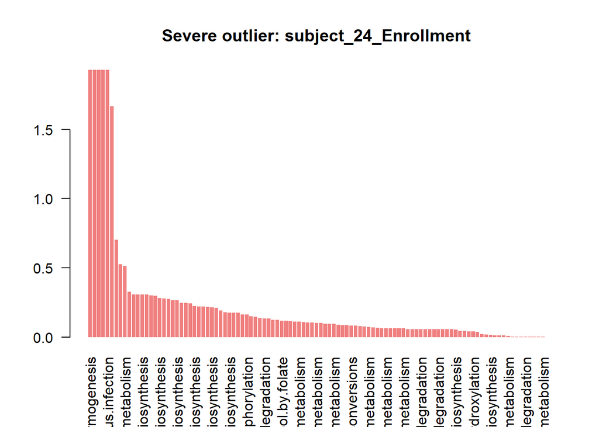

```
## There are no moderate outliers in the data or they were not computed.
```

```r
pw_top10_severe <-get_top_contrib_list(pw_sev_contrib_99$contribT2)

pw_top10_severe
```

```
## [[1]]
## # A tibble: 10 × 3
##    sample_id             pathway                             contribution
##    <chr>                 <chr>                                      <dbl>
##  1 subject_24_Enrollment Thermogenesis                              1.93
##  2 subject_24_Enrollment PI3K.Akt.signaling.pathway                 1.93
##  3 subject_24_Enrollment mTOR.signaling.pathway                     1.93
##  4 subject_24_Enrollment Relaxin.signaling.pathway                  1.93
##  5 subject_24_Enrollment Human.papillomavirus.infection             1.93
##  6 subject_24_Enrollment Glycerolipid.metabolism                    1.67
##  7 subject_24_Enrollment beta.Alanine.metabolism                    0.703
##  8 subject_24_Enrollment Aflatoxin.biosynthesis                     0.526
##  9 subject_24_Enrollment C5.Branched.dibasic.acid.metabolism        0.513
## 10 subject_24_Enrollment Citrate.cycle..TCA.cycle.                  0.325
```

# PCA — Metabolites

## Escalado centrado (`scaling = "center"`)

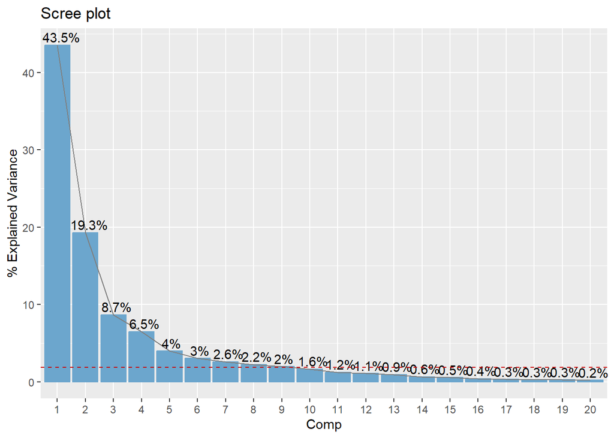

```r
metabolites_pca_ctr <- pca(metabolites_X, ncomp = NULL, algo = "nipals", scaling = "center")
pcaPlot(metabolites_pca_ctr, type = "scree")
```

### Score plots — Exposición ambiental

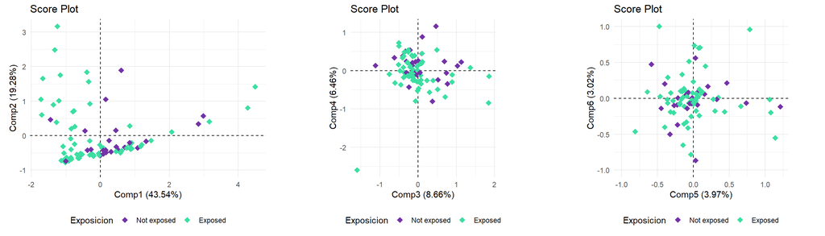

```r
p1 <- pcaPlot(metabolites_pca_ctr, type = "scores", comp = 1:2,
              colBy = data.frame(Exposicion = metabolites_meta$Exposure_to_Environmental_Factors),
              labels = FALSE, ellipses = FALSE)
p2 <- pcaPlot(metabolites_pca_ctr, type = "scores", comp = 3:4,
              colBy = data.frame(Exposicion = metabolites_meta$Exposure_to_Environmental_Factors),
              labels = FALSE, ellipses = FALSE)
p3 <- pcaPlot(metabolites_pca_ctr, type = "scores", comp = 5:6,
              colBy = data.frame(Exposicion = metabolites_meta$Exposure_to_Environmental_Factors),
              labels = FALSE, ellipses = FALSE)
grid.arrange(p1, p2, p3, nrow = 1)
```

### Score plots — Riesgo genético

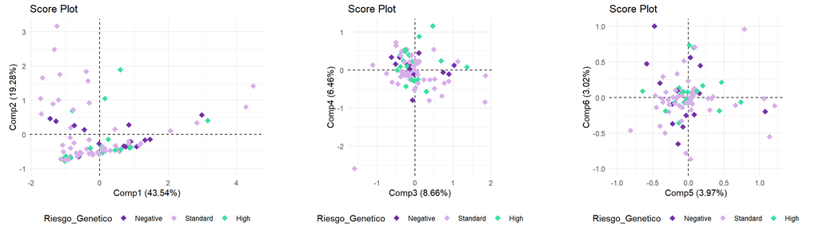

```r
p1 <- pcaPlot(metabolites_pca_ctr, type = "scores", comp = 1:2,
              colBy = data.frame(Riesgo_Genetico = metabolites_meta$Genetic_Risk_Group),
              labels = FALSE, ellipses = FALSE)
p2 <- pcaPlot(metabolites_pca_ctr, type = "scores", comp = 3:4,
              colBy = data.frame(Riesgo_Genetico = metabolites_meta$Genetic_Risk_Group),
              labels = FALSE, ellipses = FALSE)
p3 <- pcaPlot(metabolites_pca_ctr, type = "scores", comp = 5:6,
              colBy = data.frame(Riesgo_Genetico = metabolites_meta$Genetic_Risk_Group),
              labels = FALSE, ellipses = FALSE)
grid.arrange(p1, p2, p3, nrow = 1)
```

### Score plots — Tiempo

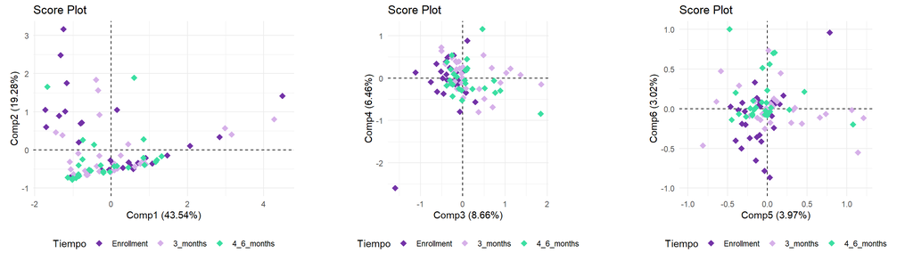

```r
p1 <- pcaPlot(metabolites_pca_ctr, type = "scores", comp = 1:2,
              colBy = data.frame(Tiempo = metabolites_time),
              labels = FALSE, ellipses = FALSE)
p2 <- pcaPlot(metabolites_pca_ctr, type = "scores", comp = 3:4,
              colBy = data.frame(Tiempo = metabolites_time),
              labels = FALSE, ellipses = FALSE)
p3 <- pcaPlot(metabolites_pca_ctr, type = "scores", comp = 5:6,
              colBy = data.frame(Tiempo = metabolites_time),
              labels = FALSE, ellipses = FALSE)
grid.arrange(p1, p2, p3, nrow = 1)
```

### Score plots — País

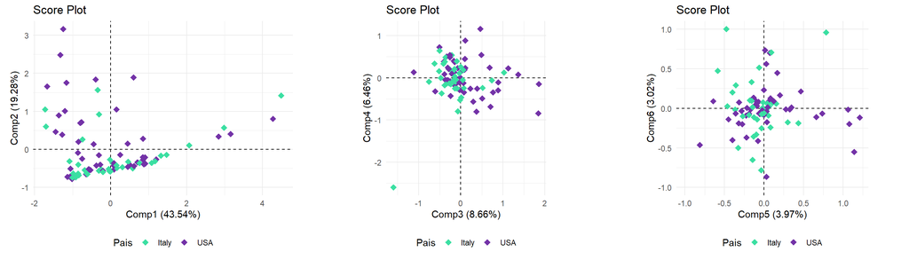

```r
p1 <- pcaPlot(metabolites_pca_ctr, type = "scores", comp = 1:2,
              colBy = data.frame(Pais = metabolites_meta$country),
              labels = FALSE, ellipses = FALSE)
p2 <- pcaPlot(metabolites_pca_ctr, type = "scores", comp = 3:4,
              colBy = data.frame(Pais = metabolites_meta$country),
              labels = FALSE, ellipses = FALSE)
p3 <- pcaPlot(metabolites_pca_ctr, type = "scores", comp = 5:6,
              colBy = data.frame(Pais = metabolites_meta$country),
              labels = FALSE, ellipses = FALSE)
grid.arrange(p1, p2, p3, nrow = 1)
```

### Score plots — Modo de parto

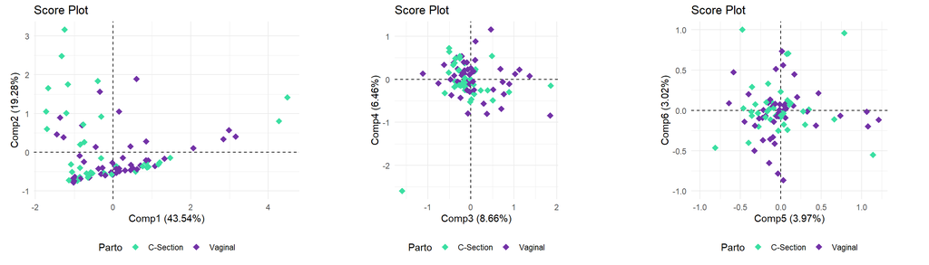

```r
p1 <- pcaPlot(metabolites_pca_ctr, type = "scores", comp = 1:2,
              colBy = data.frame(Parto = metabolites_meta$Delivery_Mode),
              labels = FALSE, ellipses = FALSE)
p2 <- pcaPlot(metabolites_pca_ctr, type = "scores", comp = 3:4,
              colBy = data.frame(Parto = metabolites_meta$Delivery_Mode),
              labels = FALSE, ellipses = FALSE)
p3 <- pcaPlot(metabolites_pca_ctr, type = "scores", comp = 5:6,
              colBy = data.frame(Parto = metabolites_meta$Delivery_Mode),
              labels = FALSE, ellipses = FALSE)
grid.arrange(p1, p2, p3, nrow = 1)
```

### Score plots — Tipo de alimentación

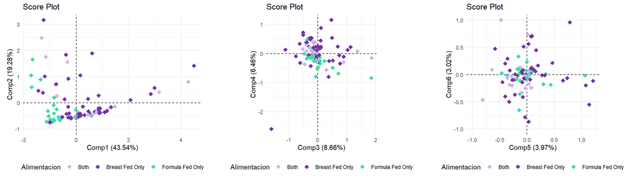

```r
p1 <- pcaPlot(metabolites_pca_ctr, type = "scores", comp = 1:2,
              colBy = data.frame(Alimentacion = metabolites_meta$Feeding_Type),
              labels = FALSE, ellipses = FALSE)
p2 <- pcaPlot(metabolites_pca_ctr, type = "scores", comp = 3:4,
              colBy = data.frame(Alimentacion = metabolites_meta$Feeding_Type),
              labels = FALSE, ellipses = FALSE)
p3 <- pcaPlot(metabolites_pca_ctr, type = "scores", comp = 5:6,
              colBy = data.frame(Alimentacion = metabolites_meta$Feeding_Type),
              labels = FALSE, ellipses = FALSE)
grid.arrange(p1, p2, p3, nrow = 1)
```

### Score plots — Sexo

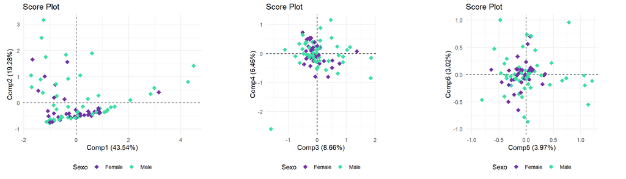

```r
p1 <- pcaPlot(metabolites_pca_ctr, type = "scores", comp = 1:2,
              colBy = data.frame(Sexo = metabolites_meta$Gender),
              labels = FALSE, ellipses = FALSE)
p2 <- pcaPlot(metabolites_pca_ctr, type = "scores", comp = 3:4,
              colBy = data.frame(Sexo = metabolites_meta$Gender),
              labels = FALSE, ellipses = FALSE)
p3 <- pcaPlot(metabolites_pca_ctr, type = "scores", comp = 5:6,
              colBy = data.frame(Sexo = metabolites_meta$Gender),
              labels = FALSE, ellipses = FALSE)
grid.arrange(p1, p2, p3, nrow = 1)
```

### Loadings — Correlation plots

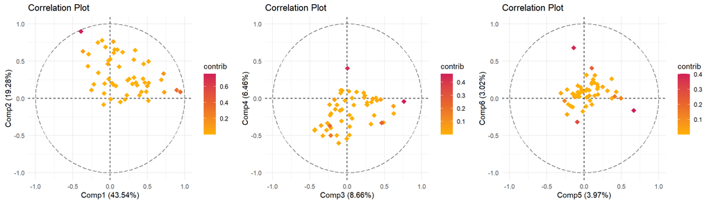

```r
l1 <- pcaPlot(metabolites_pca_ctr, type = "corr", comp = 1:2,
              colBy = "contrib", shape = "point", labels = FALSE, repel = TRUE, col = "hot")
l2 <- pcaPlot(metabolites_pca_ctr, type = "corr", comp = 3:4,
              colBy = "contrib", shape = "point", labels = FALSE, repel = TRUE, col = "hot")
l3 <- pcaPlot(metabolites_pca_ctr, type = "corr", comp = 5:6,
              colBy = "contrib", shape = "point", labels = FALSE, repel = TRUE, col = "hot")
grid.arrange(l1, l2, l3, ncol = 3)
```

### Loadings — Top 10 metabolitos

**PC1 y PC2**

```r
tibble(
  variable    = rownames(metabolites_pca_ctr$loadings),
  loading_PC1 = metabolites_pca_ctr$loadings[, 1],
  loading_PC2 = metabolites_pca_ctr$loadings[, 2]
) %>%
  mutate(contribution_PC12 = loading_PC1^2 + loading_PC2^2) %>%
  arrange(desc(contribution_PC12)) %>%
  slice_head(n = 10) %>%
  kable(caption = "Centrado — Top 10 metabolitos PC1/PC2")
```

Centrado — Top 10 metabolitos PC1/PC2

| variable | loading_PC1 | loading_PC2 | contribution_PC12 |
| --- | --- | --- | --- |
| Acetic.acid | -0.2424840 | 0.8362258 | 0.7580722 |
| Glucose..peak.2. | 0.5872336 | 0.0814725 | 0.3514811 |
| X18.Oxocorticol | 0.5646175 | 0.1062941 | 0.3300914 |
| Ribonic.acid | 0.3112010 | 0.2167482 | 0.1438258 |
| Glycine | -0.1047472 | 0.2717574 | 0.0848241 |
| Ribitol..peak.1. | 0.2656340 | 0.0450060 | 0.0725870 |
| Lactose..peak.1. | 0.0089875 | 0.2430143 | 0.0591367 |
| Ribitol..peak.2. | 0.1981257 | 0.0996697 | 0.0491879 |
| Glycerol | -0.0085084 | 0.1922494 | 0.0370322 |
| Hydrocinnamic.acid | 0.1566123 | 0.0939155 | 0.0333475 |

**PC3 y PC4**

```r
tibble(
  variable    = rownames(metabolites_pca_ctr$loadings),
  loading_PC3 = metabolites_pca_ctr$loadings[, 3],
  loading_PC4 = metabolites_pca_ctr$loadings[, 4]
) %>%
  mutate(contribution_PC34 = loading_PC3^2 + loading_PC4^2) %>%
  arrange(desc(contribution_PC34)) %>%
  slice_head(n = 10) %>%
  kable(caption = "Centrado — Top 10 metabolitos PC3/PC4")
```

Centrado — Top 10 metabolitos PC3/PC4

| variable | loading_PC3 | loading_PC4 | contribution_PC34 |
| --- | --- | --- | --- |
| Ribitol..peak.2. | 0.6805367 | -0.0437759 | 0.4650466 |
| X18.Oxocorticol | 0.0047989 | 0.6616231 | 0.4377682 |
| Ribitol..peak.1. | 0.3800929 | -0.3126371 | 0.2422126 |
| Ribonic.acid | -0.2254283 | -0.4158852 | 0.2237784 |
| Hydrocinnamic.acid | -0.1489935 | -0.3921765 | 0.1760015 |
| Glucose..peak.2. | -0.2339102 | -0.0280717 | 0.0555020 |
| Erythritol | 0.1751473 | -0.1346173 | 0.0487984 |
| Glycine | 0.2201637 | -0.0041995 | 0.0484897 |
| Serine | 0.2142641 | -0.0420797 | 0.0476798 |
| Succinic.acid | 0.2177301 | -0.0087434 | 0.0474829 |

**PC5 y PC6**

```r
tibble(
  variable    = rownames(metabolites_pca_ctr$loadings),
  loading_PC5 = metabolites_pca_ctr$loadings[, 5],
  loading_PC6 = metabolites_pca_ctr$loadings[, 6]
) %>%
  mutate(contribution_PC56 = loading_PC5^2 + loading_PC6^2) %>%
  arrange(desc(contribution_PC56)) %>%
  slice_head(n = 10) %>%
  kable(caption = "Centrado — Top 10 metabolitos PC5/PC6")
```

Centrado — Top 10 metabolitos PC5/PC6

| variable | loading_PC5 | loading_PC6 | contribution_PC56 |
| --- | --- | --- | --- |
| Glycerol | 0.6113860 | -0.1729410 | 0.4037014 |
| Melibiose..peak.1. | -0.1104593 | 0.6114671 | 0.3860933 |
| Ribonic.acid | -0.1332249 | -0.5253350 | 0.2937257 |
| Hydrocinnamic.acid | 0.1025032 | 0.4651404 | 0.2268625 |
| Glycine | 0.3885168 | 0.0277168 | 0.1517135 |
| Succinic.acid | 0.3521665 | 0.0017547 | 0.1240243 |
| Ribitol..peak.2. | -0.3445714 | -0.0479898 | 0.1210325 |
| Acetic.acid | -0.2577364 | 0.0394824 | 0.0679869 |
| Serine | -0.1589644 | 0.0401334 | 0.0268804 |
| Glucose..peak.2. | 0.1415837 | 0.0810955 | 0.0266224 |

```r
metab_pca_ctr <- pca(
  metabolites_X,
  ncomp   = 4,
  algo    = "nipals",
  scaling = "center"
)
```

### Detección de muestras anómalas (centrado)

```r
par(mfrow = c(1, 2))

metab_out_RSS_ctr <- pcaOutliers(metab_pca_ctr, ncomp = metab_pca_ctr$ncomp, method = "RSS", conf = 0.95)
metab_out_T2_ctr  <- pcaOutliers(metab_pca_ctr, ncomp = metab_pca_ctr$ncomp, method = "T2",  conf = 0.95)
```

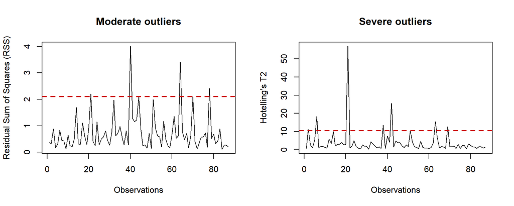

```r
par(mfrow = c(1, 1))
```

```r
metab_moderate_ctr <- sort(
  metab_out_RSS_ctr$RSS[metab_out_RSS_ctr$ModerateOutliers],
  decreasing = TRUE
)

metab_severe_ctr <- sort(
  metab_out_T2_ctr$T2[metab_out_T2_ctr$SevereOutliers],
  decreasing = TRUE
)

cat("Anómalos moderados (RSS) al 95 :\n"); print(metab_moderate_ctr)
```

```
## Anómalos moderados (RSS) al 95 :
```

```
##   subject_11_3_months  subject_4_4_6_months subject_21_4_6_months
##              4.004294              3.407667              2.411279
## subject_23_Enrollment
##              2.199542
```

```r
cat("\nAnómalos severos (T²) al 95 :\n");   print(metab_severe_ctr)
```

```
##
## Anómalos severos (T²) al 95 :
```

```
## subject_23_Enrollment   subject_13_3_months  subject_6_Enrollment
##              56.96366              25.48069              18.35895
##  subject_3_4_6_months    subject_9_3_months subject_10_4_6_months
##              15.47035              13.53805              12.73695
##  subject_2_Enrollment
##              11.19695
```

```r
par(mfrow = c(1, 2))

metab_out_RSS_99_ctr <- pcaOutliers(metab_pca_ctr, ncomp = metab_pca_ctr$ncomp, method = "RSS", conf = 0.99)
metab_out_T2_99_ctr  <- pcaOutliers(metab_pca_ctr, ncomp = metab_pca_ctr$ncomp, method = "T2",  conf = 0.99)
```

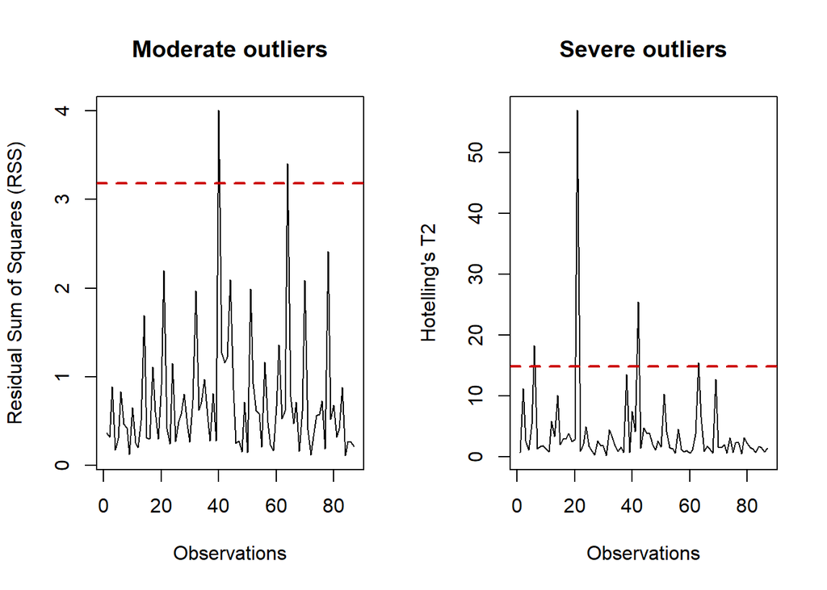

```r
par(mfrow = c(1, 1))
```

```r
metab_moderate_99_ctr <- sort(metab_out_RSS_99_ctr$RSS[metab_out_RSS_99_ctr$ModerateOutliers], decreasing = TRUE)
metab_severe_99_ctr   <- sort(metab_out_T2_99_ctr$T2[metab_out_T2_99_ctr$SevereOutliers], decreasing = TRUE)

cat("Moderados (RSS) al 99 :\n"); print(metab_moderate_99_ctr)
```

```
## Moderados (RSS) al 99 :
```

```
##  subject_11_3_months subject_4_4_6_months
##             4.004294             3.407667
```

```r
cat("Severos   (T²) al 99 :\n");  print(metab_severe_99_ctr)
```

```
## Severos   (T²) al 99 :
```

```
## subject_23_Enrollment   subject_13_3_months  subject_6_Enrollment
##              56.96366              25.48069              18.35895
##  subject_3_4_6_months
##              15.47035
```

```r
metab_mod_contrib_99_ctr <- outlierContrib(metab_pca_ctr, metab_out_RSS_99_ctr)
```

```
## There are no severe outliers in the data or they were not computed.
```

```
## There are 2 moderate outliers in the data provided.
```

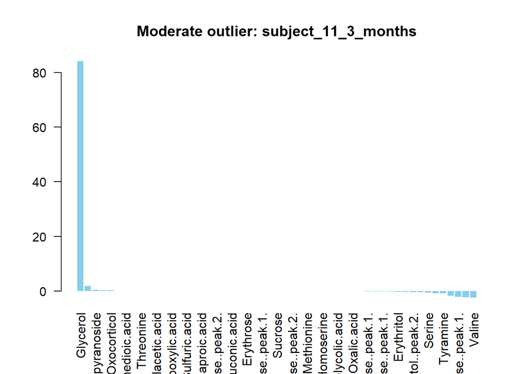

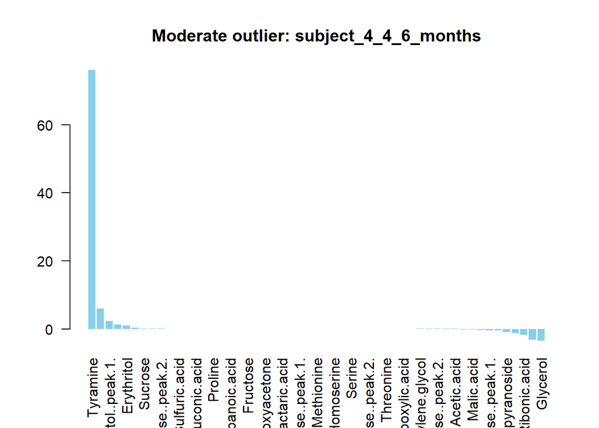

```r
metab_top10_moderate_ctr <- get_top_contrib_list(metab_mod_contrib_99_ctr$contribRSS)
metab_top10_moderate_ctr
```

```
## [[1]]
## # A tibble: 10 × 3
##    sample_id           pathway          contribution
##    <chr>               <chr>                   <dbl>
##  1 subject_11_3_months Glycerol               84.1
##  2 subject_11_3_months Valine                 -2.36
##  3 subject_11_3_months Acetic.acid            -2.28
##  4 subject_11_3_months Lactose..peak.1.       -2.15
##  5 subject_11_3_months Ribonic.acid            1.92
##  6 subject_11_3_months Glucose..peak.2.       -1.65
##  7 subject_11_3_months Tyramine               -0.869
##  8 subject_11_3_months Ribitol..peak.1.       -0.866
##  9 subject_11_3_months Serine                 -0.628
## 10 subject_11_3_months Malic.acid             -0.487
##
## [[2]]
## # A tibble: 10 × 3
##    sample_id            pathway                 contribution
##    <chr>                <chr>                          <dbl>
##  1 subject_4_4_6_months Tyramine                      76.1
##  2 subject_4_4_6_months Lactose..peak.1.               6.00
##  3 subject_4_4_6_months Glycerol                      -3.42
##  4 subject_4_4_6_months Succinic.acid                 -3.18
##  5 subject_4_4_6_months Ribitol..peak.1.               2.29
##  6 subject_4_4_6_months Ribonic.acid                  -1.72
##  7 subject_4_4_6_months Ribitol..peak.2.              -1.27
##  8 subject_4_4_6_months Valine                         1.22
##  9 subject_4_4_6_months Erythritol                     1.05
## 10 subject_4_4_6_months alpha.D.Glucopyranoside       -0.927
```

```r
metab_sev_contrib_99_ctr <- outlierContrib(metab_pca_ctr, metab_out_T2_99_ctr)
```

```
## There are 4 severe outliers in the data provided.
```

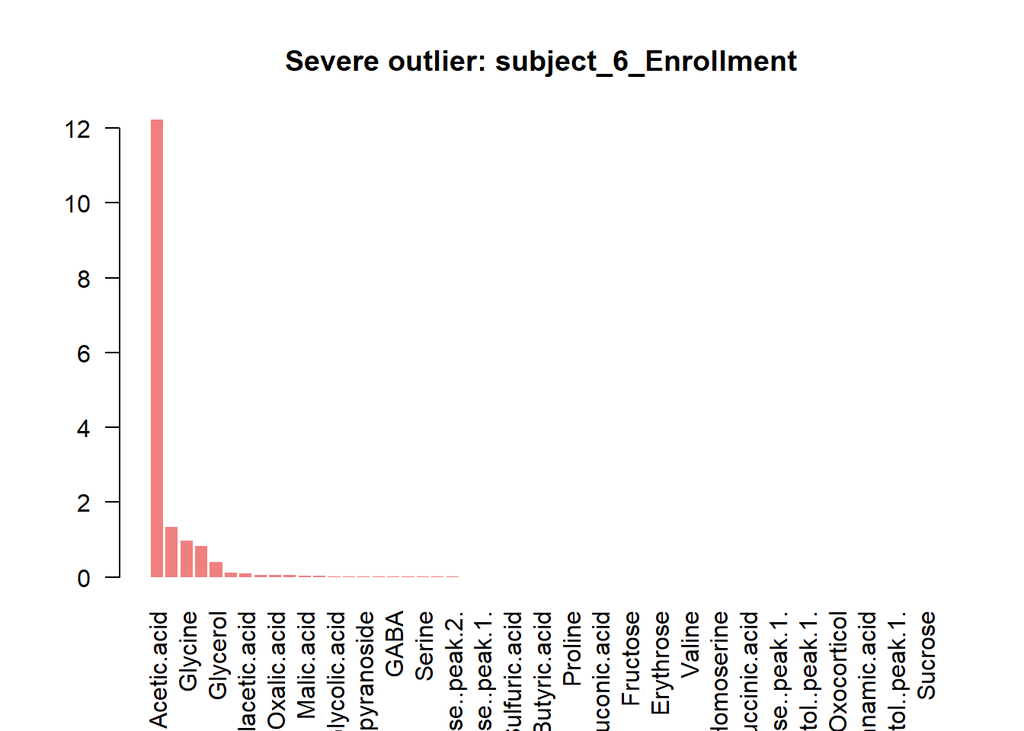

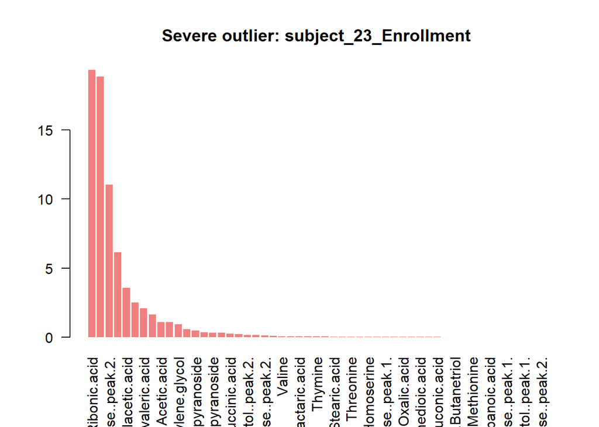

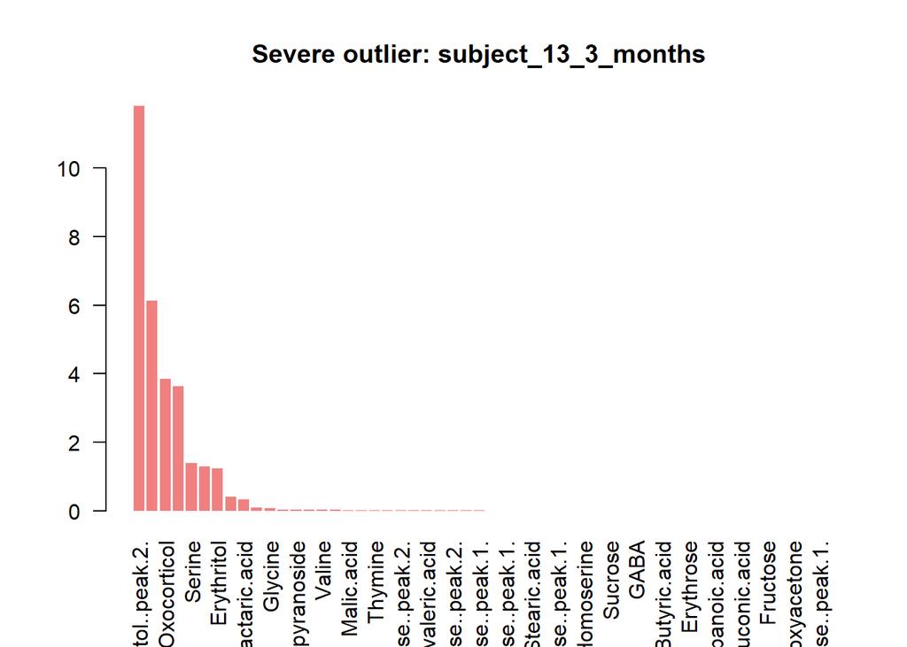

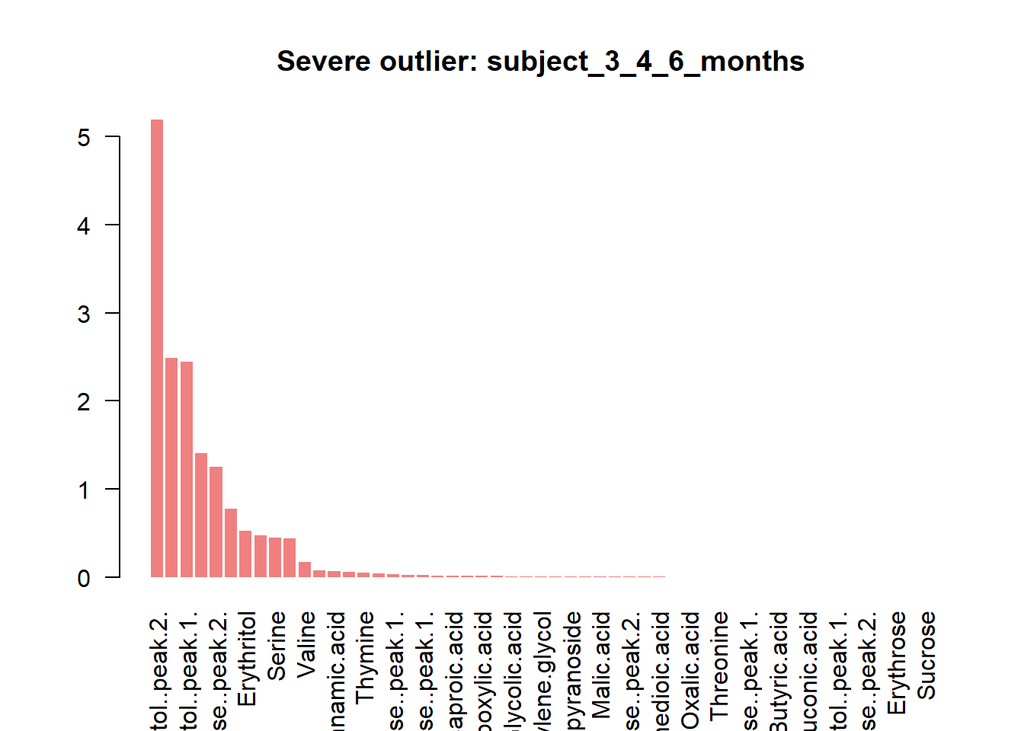

```
## There are no moderate outliers in the data or they were not computed.
```

```r
metab_top10_severe_ctr   <- get_top_contrib_list(metab_sev_contrib_99_ctr$contribT2)
metab_top10_severe_ctr
```

```
## [[1]]
## # A tibble: 10 × 3
##    sample_id            pathway                  contribution
##    <chr>                <chr>                           <dbl>
##  1 subject_6_Enrollment Acetic.acid                   12.2
##  2 subject_6_Enrollment Lactose..peak.1.               1.33
##  3 subject_6_Enrollment Glycine                        0.968
##  4 subject_6_Enrollment Ribonic.acid                   0.824
##  5 subject_6_Enrollment Glycerol                       0.397
##  6 subject_6_Enrollment Arabinonic.acid                0.120
##  7 subject_6_Enrollment Hydroxyphenylacetic.acid       0.104
##  8 subject_6_Enrollment Dihydroxyacetone               0.0639
##  9 subject_6_Enrollment Oxalic.acid                    0.0567
## 10 subject_6_Enrollment Threonine                      0.0530
##
## [[2]]
## # A tibble: 10 × 3
##    sample_id             pathway                   contribution
##    <chr>                 <chr>                            <dbl>
##  1 subject_23_Enrollment Ribonic.acid                     19.4
##  2 subject_23_Enrollment Hydrocinnamic.acid               18.9
##  3 subject_23_Enrollment Glucose..peak.2.                 11.1
##  4 subject_23_Enrollment Ribitol..peak.1.                  6.15
##  5 subject_23_Enrollment Hydroxyphenylacetic.acid          3.57
##  6 subject_23_Enrollment X18.Oxocorticol                   2.49
##  7 subject_23_Enrollment X2.Hydroxyisovaleric.acid         2.07
##  8 subject_23_Enrollment Lactose..peak.1.                  1.62
##  9 subject_23_Enrollment Acetic.acid                       1.09
## 10 subject_23_Enrollment Glycolic.acid                     1.08
##
## [[3]]
## # A tibble: 10 × 3
##    sample_id           pathway          contribution
##    <chr>               <chr>                   <dbl>
##  1 subject_13_3_months Ribitol..peak.2.      11.8
##  2 subject_13_3_months Ribitol..peak.1.       6.14
##  3 subject_13_3_months X18.Oxocorticol        3.84
##  4 subject_13_3_months Glucose..peak.2.       3.63
##  5 subject_13_3_months Serine                 1.39
##  6 subject_13_3_months Ribonic.acid           1.29
##  7 subject_13_3_months Erythritol             1.24
##  8 subject_13_3_months Acetic.acid            0.405
##  9 subject_13_3_months Galactaric.acid        0.337
## 10 subject_13_3_months Glycolic.acid          0.0894
##
## [[4]]
## # A tibble: 10 × 3
##    sample_id            pathway          contribution
##    <chr>                <chr>                   <dbl>
##  1 subject_3_4_6_months Ribitol..peak.2.        5.19
##  2 subject_3_4_6_months X18.Oxocorticol         2.49
##  3 subject_3_4_6_months Ribitol..peak.1.        2.44
##  4 subject_3_4_6_months Succinic.acid           1.40
##  5 subject_3_4_6_months Glucose..peak.2.        1.25
##  6 subject_3_4_6_months Glycine                 0.771
##  7 subject_3_4_6_months Erythritol              0.528
##  8 subject_3_4_6_months Ribonic.acid            0.476
##  9 subject_3_4_6_months Serine                  0.448
## 10 subject_3_4_6_months Acetic.acid             0.436
```

## Escalado estándar (`scaling = "standard"`)

### Cálculo y scree plot

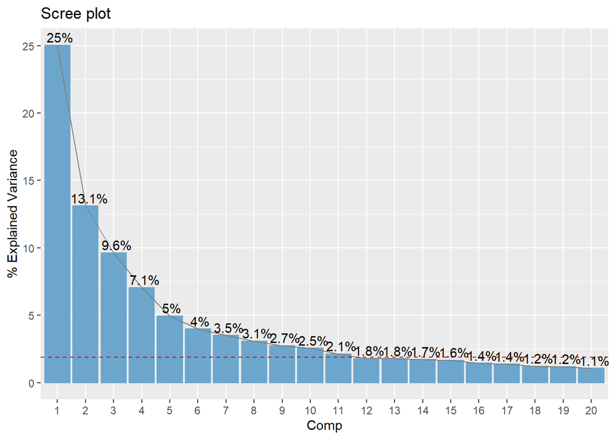

```r
metabolites_pca_std <- pca(metabolites_X, ncomp = NULL, algo = "nipals", scaling = "standard")
pcaPlot(metabolites_pca_std, type = "scree")
```

### Score plots — Exposición ambiental

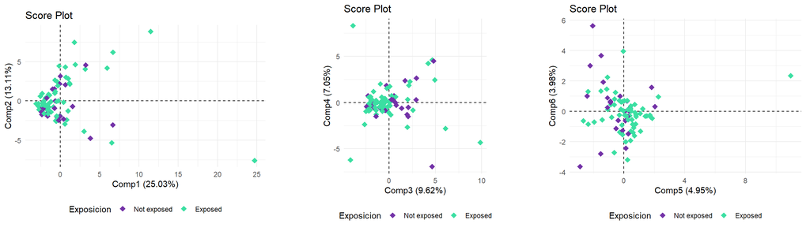

```r
p1 <- pcaPlot(metabolites_pca_std, type = "scores", comp = 1:2,
              colBy = data.frame(Exposicion = metabolites_meta$Exposure_to_Environmental_Factors),
              labels = FALSE, ellipses = FALSE)
p2 <- pcaPlot(metabolites_pca_std, type = "scores", comp = 3:4,
              colBy = data.frame(Exposicion = metabolites_meta$Exposure_to_Environmental_Factors),
              labels = FALSE, ellipses = FALSE)
p3 <- pcaPlot(metabolites_pca_std, type = "scores", comp = 5:6,
              colBy = data.frame(Exposicion = metabolites_meta$Exposure_to_Environmental_Factors),
              labels = FALSE, ellipses = FALSE)
grid.arrange(p1, p2, p3, nrow = 1)
```

### Score plots — Riesgo genético

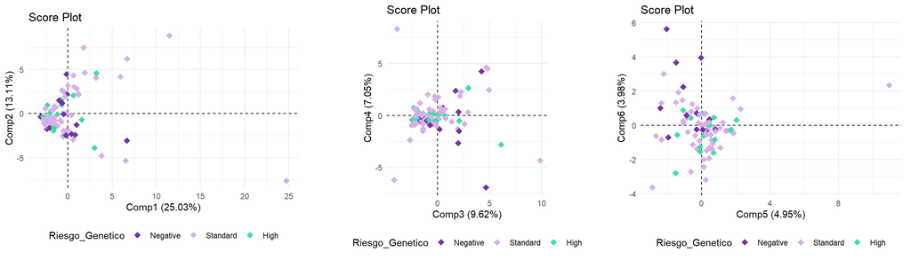

```r
p1 <- pcaPlot(metabolites_pca_std, type = "scores", comp = 1:2,
              colBy = data.frame(Riesgo_Genetico = metabolites_meta$Genetic_Risk_Group),
              labels = FALSE, ellipses = FALSE)
p2 <- pcaPlot(metabolites_pca_std, type = "scores", comp = 3:4,
              colBy = data.frame(Riesgo_Genetico = metabolites_meta$Genetic_Risk_Group),
              labels = FALSE, ellipses = FALSE)
p3 <- pcaPlot(metabolites_pca_std, type = "scores", comp = 5:6,
              colBy = data.frame(Riesgo_Genetico = metabolites_meta$Genetic_Risk_Group),
              labels = FALSE, ellipses = FALSE)
grid.arrange(p1, p2, p3, nrow = 1)
```

### Score plots — Tiempo

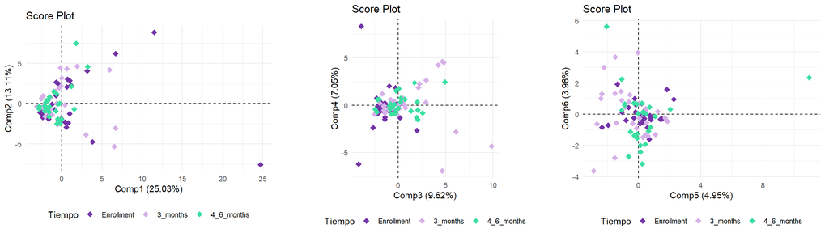

```r
p1 <- pcaPlot(metabolites_pca_std, type = "scores", comp = 1:2,
              colBy = data.frame(Tiempo = metabolites_time),
              labels = FALSE, ellipses = FALSE)
p2 <- pcaPlot(metabolites_pca_std, type = "scores", comp = 3:4,
              colBy = data.frame(Tiempo = metabolites_time),
              labels = FALSE, ellipses = FALSE)
p3 <- pcaPlot(metabolites_pca_std, type = "scores", comp = 5:6,
              colBy = data.frame(Tiempo = metabolites_time),
              labels = FALSE, ellipses = FALSE)
grid.arrange(p1, p2, p3, nrow = 1)
```

### Score plots — País

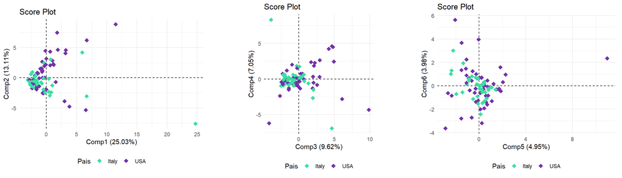

```r
p1 <- pcaPlot(metabolites_pca_std, type = "scores", comp = 1:2,
              colBy = data.frame(Pais = metabolites_meta$country),
              labels = FALSE, ellipses = FALSE)
p2 <- pcaPlot(metabolites_pca_std, type = "scores", comp = 3:4,
              colBy = data.frame(Pais = metabolites_meta$country),
              labels = FALSE, ellipses = FALSE)
p3 <- pcaPlot(metabolites_pca_std, type = "scores", comp = 5:6,
              colBy = data.frame(Pais = metabolites_meta$country),
              labels = FALSE, ellipses = FALSE)
grid.arrange(p1, p2, p3, nrow = 1)
```

### Score plots — Modo de parto

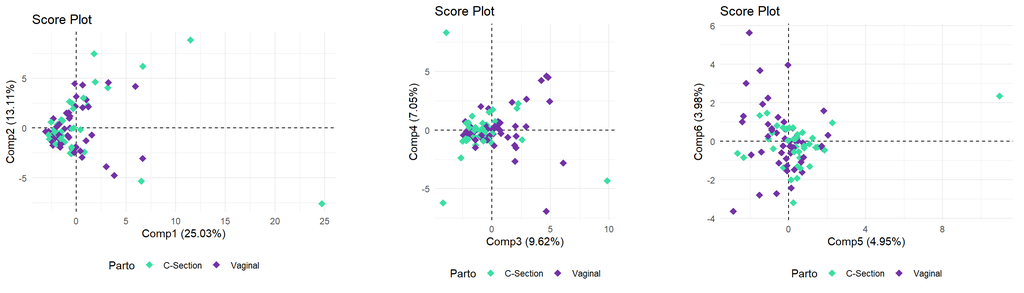

```r
p1 <- pcaPlot(metabolites_pca_std, type = "scores", comp = 1:2,
              colBy = data.frame(Parto = metabolites_meta$Delivery_Mode),
              labels = FALSE, ellipses = FALSE)
p2 <- pcaPlot(metabolites_pca_std, type = "scores", comp = 3:4,
              colBy = data.frame(Parto = metabolites_meta$Delivery_Mode),
              labels = FALSE, ellipses = FALSE)
p3 <- pcaPlot(metabolites_pca_std, type = "scores", comp = 5:6,
              colBy = data.frame(Parto = metabolites_meta$Delivery_Mode),
              labels = FALSE, ellipses = FALSE)
grid.arrange(p1, p2, p3, nrow = 1)
```

### Score plots — Tipo de alimentación

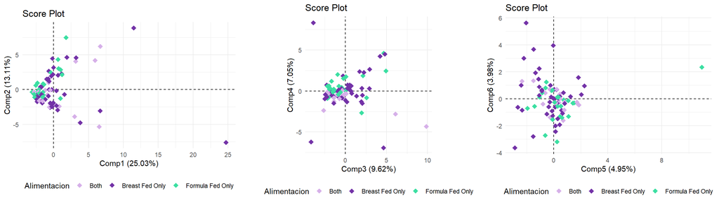

```r
p1 <- pcaPlot(metabolites_pca_std, type = "scores", comp = 1:2,
              colBy = data.frame(Alimentacion = metabolites_meta$Feeding_Type),
              labels = FALSE, ellipses = FALSE)
p2 <- pcaPlot(metabolites_pca_std, type = "scores", comp = 3:4,
              colBy = data.frame(Alimentacion = metabolites_meta$Feeding_Type),
              labels = FALSE, ellipses = FALSE)
p3 <- pcaPlot(metabolites_pca_std, type = "scores", comp = 5:6,
              colBy = data.frame(Alimentacion = metabolites_meta$Feeding_Type),
              labels = FALSE, ellipses = FALSE)
grid.arrange(p1, p2, p3, nrow = 1)
```

### Score plots — Sexo

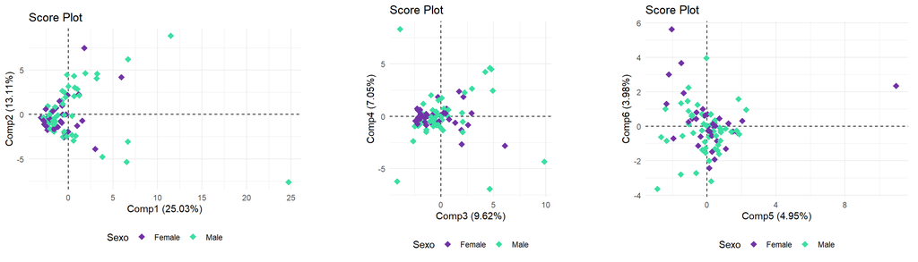

```r
p1 <- pcaPlot(metabolites_pca_std, type = "scores", comp = 1:2,
              colBy = data.frame(Sexo = metabolites_meta$Gender),
              labels = FALSE, ellipses = FALSE)
p2 <- pcaPlot(metabolites_pca_std, type = "scores", comp = 3:4,
              colBy = data.frame(Sexo = metabolites_meta$Gender),
              labels = FALSE, ellipses = FALSE)
p3 <- pcaPlot(metabolites_pca_std, type = "scores", comp = 5:6,
              colBy = data.frame(Sexo = metabolites_meta$Gender),
              labels = FALSE, ellipses = FALSE)
grid.arrange(p1, p2, p3, nrow = 1)
```

### Loadings — Correlation plots

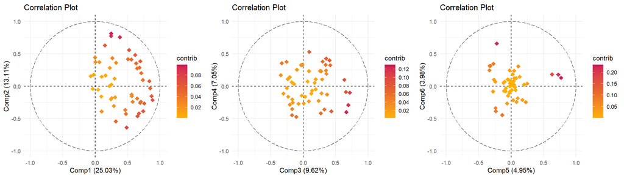

```r
l1 <- pcaPlot(metabolites_pca_std, type = "corr", comp = 1:2,
              colBy = "contrib", shape = "point", labels = FALSE, repel = TRUE, col = "hot")
l2 <- pcaPlot(metabolites_pca_std, type = "corr", comp = 3:4,
              colBy = "contrib", shape = "point", labels = FALSE, repel = TRUE, col = "hot")
l3 <- pcaPlot(metabolites_pca_std, type = "corr", comp = 5:6,
              colBy = "contrib", shape = "point", labels = FALSE, repel = TRUE, col = "hot")
grid.arrange(l1, l2, l3, ncol = 3)
```

### Loadings — Top 10 metabolitos

**PC1 y PC2**

```r
tibble(
  variable    = rownames(metabolites_pca_std$loadings),
  loading_PC1 = metabolites_pca_std$loadings[, 1],
  loading_PC2 = metabolites_pca_std$loadings[, 2]
) %>%
  mutate(contribution_PC12 = loading_PC1^2 + loading_PC2^2) %>%
  arrange(desc(contribution_PC12)) %>%
  slice_head(n = 10) %>%
  kable(caption = "Estándar — Top 10 metabolitos PC1/PC2")
```

Estándar — Top 10 metabolitos PC1/PC2

| variable | loading_PC1 | loading_PC2 | contribution_PC12 |
| --- | --- | --- | --- |
| Glycine | 0.0677873 | 0.3082639 | 0.0996218 |
| Acetic.acid | 0.1050538 | 0.2873677 | 0.0936165 |
| Sulfuric.acid | 0.0677010 | 0.2947810 | 0.0914793 |
| Glucose..peak.2. | 0.1334155 | -0.2421697 | 0.0764458 |
| Dihydroxyacetone | 0.1436511 | 0.2125996 | 0.0658342 |
| Hydroxyphenylacetic.acid | 0.2432537 | -0.0807926 | 0.0656998 |
| Glycolic.acid | 0.1798001 | -0.1764287 | 0.0634552 |
| Hydrocinnamic.acid | 0.2038370 | -0.1460906 | 0.0628920 |
| Threonine | 0.1696956 | 0.1830637 | 0.0623089 |
| Gluconic.acid | 0.2389190 | -0.0579335 | 0.0604386 |

**PC3 y PC4**

```r
tibble(
  variable    = rownames(metabolites_pca_std$loadings),
  loading_PC3 = metabolites_pca_std$loadings[, 3],
  loading_PC4 = metabolites_pca_std$loadings[, 4]
) %>%
  mutate(contribution_PC34 = loading_PC3^2 + loading_PC4^2) %>%
  arrange(desc(contribution_PC34)) %>%
  slice_head(n = 10) %>%
  kable(caption = "Estándar — Top 10 metabolitos PC3/PC4")
```

Estándar — Top 10 metabolitos PC3/PC4

| variable | loading_PC3 | loading_PC4 | contribution_PC34 |
| --- | --- | --- | --- |
| Serine | 0.2952742 | -0.2082098 | 0.1305382 |
| Ribitol..peak.2. | 0.3089174 | -0.1510936 | 0.1182592 |
| X1.2.4.Butanetriol | 0.3188677 | -0.0520091 | 0.1043816 |
| Ribitol..peak.1. | 0.2917511 | -0.0469207 | 0.0873203 |
| Erythritol | 0.2814699 | 0.0515113 | 0.0818787 |
| Galactaric.acid | 0.1931245 | -0.2006797 | 0.0775694 |
| Proline | 0.0410531 | 0.2735742 | 0.0765282 |
| X4.Hydroxycyclohexylcarboxylic.acid | 0.1799456 | 0.2061581 | 0.0748816 |
| Glucose..peak.1. | 0.1573637 | 0.2210859 | 0.0736423 |
| Oxalic.acid | -0.0467558 | -0.2460919 | 0.0627473 |

**PC5 y PC6**

```r
tibble(
  variable    = rownames(metabolites_pca_std$loadings),
  loading_PC5 = metabolites_pca_std$loadings[, 5],
  loading_PC6 = metabolites_pca_std$loadings[, 6]
) %>%
  mutate(contribution_PC56 = loading_PC5^2 + loading_PC6^2) %>%
  arrange(desc(contribution_PC56)) %>%
  slice_head(n = 10) %>%
  kable(caption = "Estándar — Top 10 metabolitos PC5/PC6")
```

Estándar — Top 10 metabolitos PC5/PC6

| variable | loading_PC5 | loading_PC6 | contribution_PC56 |
| --- | --- | --- | --- |
| Sucrose | 0.4751055 | 0.0889692 | 0.2336407 |
| Mannitol..peak.1. | -0.1372272 | 0.4538699 | 0.2248292 |
| Melibiose..peak.2. | 0.4488175 | 0.1235023 | 0.2166900 |
| Tyramine | 0.3889094 | 0.1251656 | 0.1669170 |
| Malic.acid | -0.0844081 | -0.3055744 | 0.1005004 |
| Succinic.acid | -0.1457845 | -0.2662337 | 0.0921335 |
| alpha.D.Glucopyranoside | -0.2045138 | 0.2156518 | 0.0883316 |
| Glucose..peak.1. | -0.1965625 | 0.2164978 | 0.0855081 |
| Galactaric.acid | -0.1685474 | 0.2389221 | 0.0854920 |
| Homoserine | -0.1474274 | -0.2327549 | 0.0759097 |

```r
metab_pca_std <- pca(
  metabolites_X,
  ncomp   = 4,
  algo    = "nipals",
  scaling = "standard"
)
```

## 4.4 Detección de muestras anómalas

Se detectan muestras anómalas mediante dos criterios complementarios. El RSS y el T² de Hotelling. Las muestras detectadas se identifican pero **no se eliminan**.

```r
par(mfrow = c(1, 2))

metab_out_RSS <- pcaOutliers(metab_pca_std, ncomp = metab_pca_std$ncomp,method = "RSS", conf = 0.95)
metab_out_T2  <- pcaOutliers(metab_pca_std, ncomp = metab_pca_std$ncomp,method = "T2",  conf = 0.95)
```

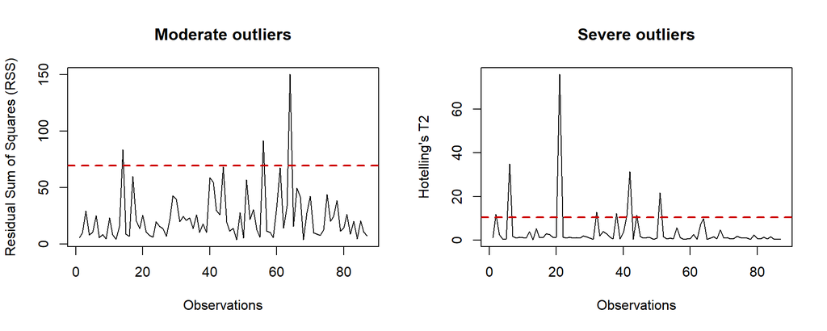

```r
par(mfrow = c(1, 1))
```

```r
metab_moderate <- sort(
  metab_out_RSS$RSS[metab_out_RSS$ModerateOutliers],
  decreasing = TRUE
)

metab_severe <- sort(
  metab_out_T2$T2[metab_out_T2$SevereOutliers],
  decreasing = TRUE
)

cat("Anómalos moderados (RSS) al 95 :\n"); print(metab_moderate)
```

```
## Anómalos moderados (RSS) al 95 :
```

```
##  subject_4_4_6_months   subject_27_3_months subject_15_Enrollment
##             150.10809              91.30033              83.38885
```

```r
cat("\nAnómalos severos (T²) al 95 :\n");   print(metab_severe)
```

```
##
## Anómalos severos (T²) al 95 :
```

```
## subject_23_Enrollment  subject_6_Enrollment   subject_13_3_months
##              75.91657              34.97447              31.35455
##   subject_22_3_months    subject_3_3_months    subject_9_3_months
##              21.76724              12.72664              12.23802
##  subject_2_Enrollment   subject_15_3_months   subject_12_3_months
##              11.80216              11.39560              11.19486
```

```r
par(mfrow = c(1, 2))

metab_out_RSS_99 <- pcaOutliers(metab_pca_std, ncomp = metab_pca_std$ncomp,method = "RSS", conf = 0.99)
metab_out_T2_99  <- pcaOutliers(metab_pca_std, ncomp = metab_pca_std$ncomp,method = "T2",  conf = 0.99)
```

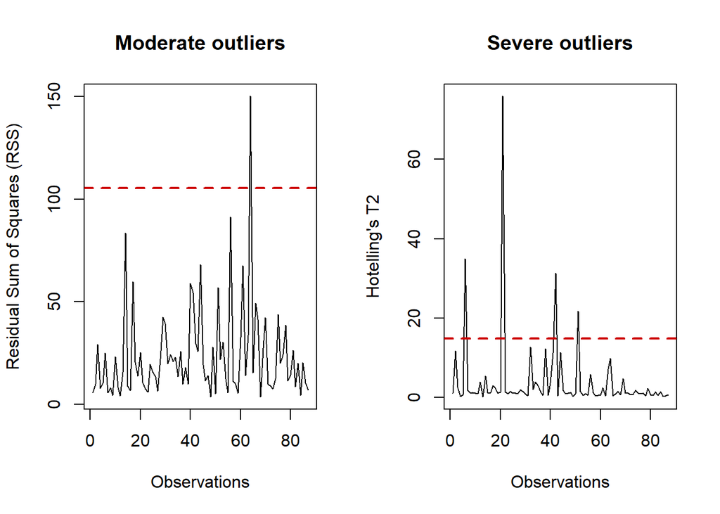

```r
par(mfrow = c(1, 1))
```

```r
metab_moderate_99 <- sort(metab_out_RSS_99$RSS[metab_out_RSS_99$ModerateOutliers],
                    decreasing = TRUE)
metab_severe_99   <- sort(metab_out_T2_99$T2[metab_out_T2_99$SevereOutliers],
                    decreasing = TRUE)

cat("Moderados (RSS) al 99 :\n"); print(metab_moderate_99)
```

```
## Moderados (RSS) al 99 :
```

```
## subject_4_4_6_months
##             150.1081
```

```r
cat("Severos   (T²) al 99 :\n");  print(metab_severe_99)
```

```
## Severos   (T²) al 99 :
```

```
## subject_23_Enrollment  subject_6_Enrollment   subject_13_3_months
##              75.91657              34.97447              31.35455
##   subject_22_3_months
##              21.76724
```

```r
metab_mod_contrib_99 <- outlierContrib(metab_pca_std, metab_out_RSS_99)
```

```
## There are no severe outliers in the data or they were not computed.
```

```
## There are 1 moderate outliers in the data provided.
```

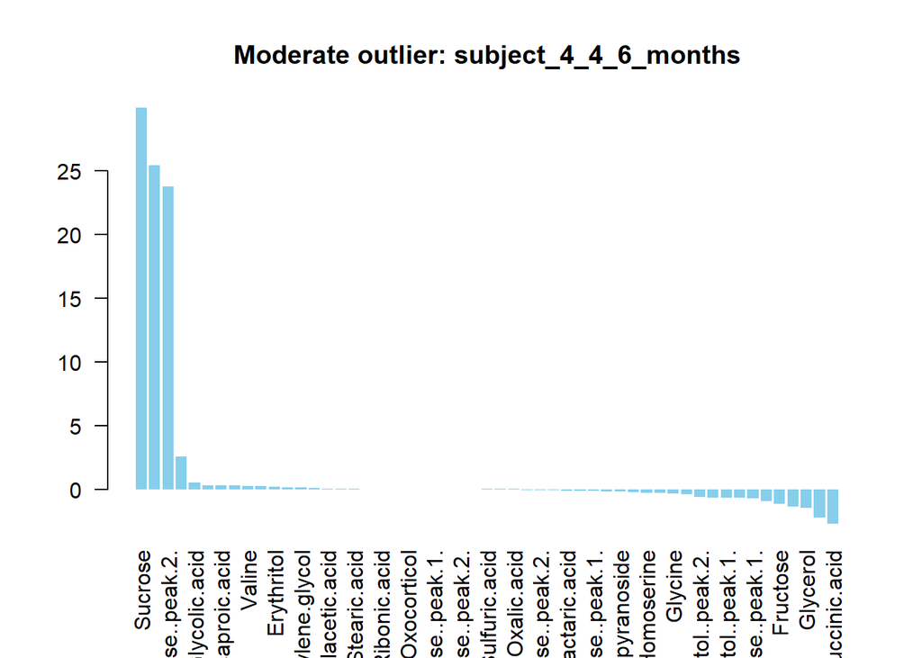

```r
metab_sev_contrib_99 <- outlierContrib(metab_pca_std, metab_out_T2_99)
```

```
## There are 4 severe outliers in the data provided.
```

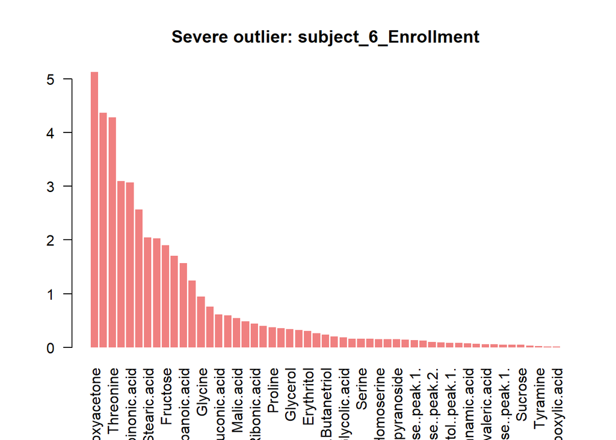

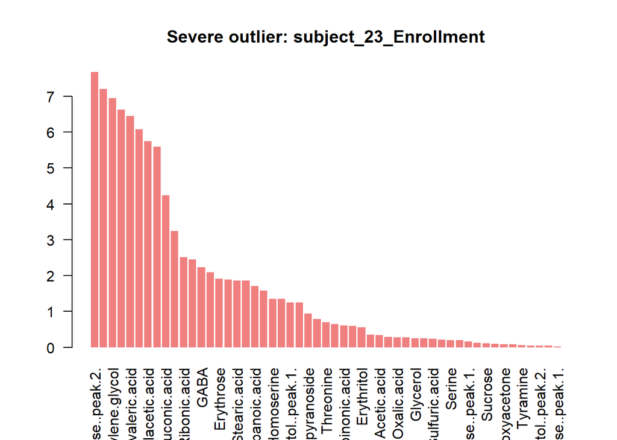

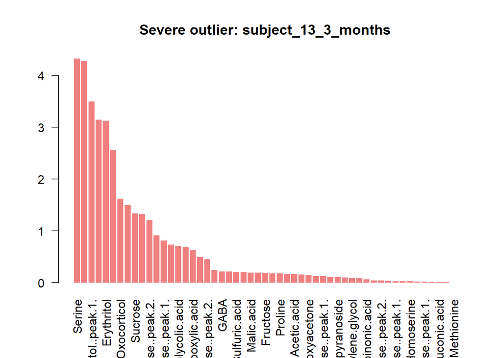

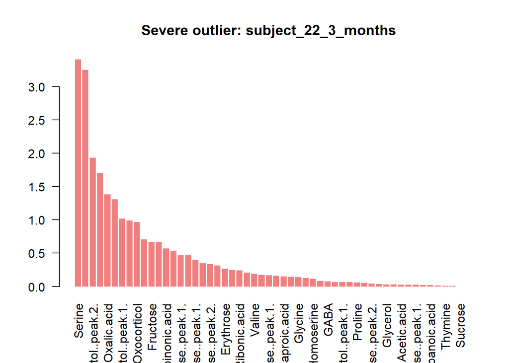

```
## There are no moderate outliers in the data or they were not computed.
```

```r
metab_top10_moderate <- get_top_contrib_list(metab_mod_contrib_99$contribRSS)


metab_top10_moderate
```

```
## [[1]]
## # A tibble: 10 × 3
##    sample_id            pathway            contribution
##    <chr>                <chr>                     <dbl>
##  1 subject_4_4_6_months Sucrose                  29.9
##  2 subject_4_4_6_months Tyramine                 25.4
##  3 subject_4_4_6_months Melibiose..peak.2.       23.7
##  4 subject_4_4_6_months Succinic.acid            -2.68
##  5 subject_4_4_6_months Lactose..peak.1.          2.55
##  6 subject_4_4_6_months Arabinonic.acid          -2.23
##  7 subject_4_4_6_months Glycerol                 -1.44
##  8 subject_4_4_6_months Malic.acid               -1.37
##  9 subject_4_4_6_months Fructose                 -1.14
## 10 subject_4_4_6_months Butanedioic.acid         -0.931
```

```r
metab_top10_severe <-get_top_contrib_list(metab_sev_contrib_99$contribT2)

metab_top10_severe
```

```
## [[1]]
## # A tibble: 10 × 3
##    sample_id            pathway          contribution
##    <chr>                <chr>                   <dbl>
##  1 subject_6_Enrollment Dihydroxyacetone         5.13
##  2 subject_6_Enrollment Oxalic.acid              4.37
##  3 subject_6_Enrollment Threonine                4.28
##  4 subject_6_Enrollment Acetic.acid              3.09
##  5 subject_6_Enrollment Arabinonic.acid          3.07
##  6 subject_6_Enrollment Lactose..peak.1.         2.56
##  7 subject_6_Enrollment Stearic.acid             2.04
##  8 subject_6_Enrollment GABA                     2.03
##  9 subject_6_Enrollment Fructose                 1.90
## 10 subject_6_Enrollment Butanedioic.acid         1.70
##
## [[2]]
## # A tibble: 10 × 3
##    sample_id             pathway                   contribution
##    <chr>                 <chr>                            <dbl>
##  1 subject_23_Enrollment Lactose..peak.2.                  7.67
##  2 subject_23_Enrollment Hydrocinnamic.acid                7.19
##  3 subject_23_Enrollment Diethylene.glycol                 6.95
##  4 subject_23_Enrollment X2.Hydroxyisocaproic.acid         6.63
##  5 subject_23_Enrollment X2.Hydroxyisovaleric.acid         6.45
##  6 subject_23_Enrollment Proline                           6.07
##  7 subject_23_Enrollment Hydroxyphenylacetic.acid          5.74
##  8 subject_23_Enrollment Butyric.acid                      5.59
##  9 subject_23_Enrollment Gluconic.acid                     4.24
## 10 subject_23_Enrollment Galactose..peak.2.                3.24
##
## [[3]]
## # A tibble: 10 × 3
##    sample_id           pathway            contribution
##    <chr>               <chr>                     <dbl>
##  1 subject_13_3_months Serine                     4.32
##  2 subject_13_3_months Ribitol..peak.2.           4.28
##  3 subject_13_3_months Ribitol..peak.1.           3.49
##  4 subject_13_3_months X1.2.4.Butanetriol         3.15
##  5 subject_13_3_months Erythritol                 3.12
##  6 subject_13_3_months Galactaric.acid            2.56
##  7 subject_13_3_months X18.Oxocorticol            1.62
##  8 subject_13_3_months Butanedioic.acid           1.49
##  9 subject_13_3_months Sucrose                    1.34
## 10 subject_13_3_months Ribose..peak.1.            1.32
##
## [[4]]
## # A tibble: 10 × 3
##    sample_id           pathway          contribution
##    <chr>               <chr>                   <dbl>
##  1 subject_22_3_months Serine                  3.41
##  2 subject_22_3_months Methionine              3.25
##  3 subject_22_3_months Ribitol..peak.2.        1.93
##  4 subject_22_3_months Galactaric.acid         1.70
##  5 subject_22_3_months Oxalic.acid             1.38
##  6 subject_22_3_months Threonine               1.31
##  7 subject_22_3_months Ribitol..peak.1.        1.02
##  8 subject_22_3_months Butanedioic.acid        0.990
##  9 subject_22_3_months X18.Oxocorticol         0.967
## 10 subject_22_3_months Dihydroxyacetone        0.708
```